# Coursework #2 AI for Sustainable Development

## Coursework overview

Coursework #2 is a data analysis coding-based coursework. You are asked to choose a dataset related to sustainable development and do some machine learning based analysis. We will detail this more in the next sections.

You can choose an application/dataset from the ones we analysed in the first coursework or choose a completely new dataset:

- **Option 1**: Choose a dataset from the SustainBench paper (which includes 15 datasets related to sustainable development). There is no restriction regarding the dataset, you can even choose the same dataset that you use in coursework #1. Please note that the authors from SustainBench have a GitHub project with data loaders, preprocessing code and baselines for these datasets here: https://github.com/sustainlab-group/sustainbench
- **Option 2**: Choose an alternative dataset of your choice (that you are interested in or that you plan on working on for your MSc dissertation). Please if you choose this option motivate the dataset's relationship to sustainable development.

Once you have chosen your dataset we will ask you to do the following:

1. Do some **exploratory data analysis** to get some insights about the dataset. We do not give specific guidelines here as this may depend on the dataset itself, but we ask you to justify your choices and the results of your analysis.
2. Think about the **task that the dataset is most suitable for** and discuss what would be the most **appropriate evaluation criteria** for such a machine learning task. For example, you may have a dataset where songs are labelled with different music genres. Perhaps the task for which the dataset is most suitable for is to build a multi label prediction model that can classify new songs, and the most appropriate evaluation metric could be the hamming loss (commonly used in multi label prediction, which could be used both as inspiration for a training objective for neural networks, or simply as the evaluation criteria for model selection and hyperparameter tuning).
3. **Design and implement a machine learning system/pipeline**. This could be either supervised or unsupervised.
4. **Design a set of experiments** and discuss how these fit with the questions that the dataset aims to address. Do a **performance & scalability analysis** of your model.
5. Discuss/analyse the **ethical implications**, in connection with your exploratory data analysis and model performance (e.g. do you appreciate any imbalances in the data or initial biases that can be problematic?).
6. Discuss **sustainable development relevance & impact**.

We ask your code to be in python, but beyond that we do not mind what packages you use.

For grading, we will not check your code in depth (beyond perhaps checking that it's doing what you describe). Instead, our focus will be on grading the analysis you have done, how well it's motivated and justified, how insightful it was, how do you interpret the results in terms of impact and sustainable development, etc.

**Submission**: You do not have to submit your dataset and notebook to the coursework submission. Simply run the analysis in jupyter notebooks and then export the notebook as html or pdf. You can submit this html/pdf file in moodle.

### Previous work (5%)

**Guidelines**: We first ask you to summarise what has been done before with this dataset. While this is not specifically necessary for the purpose of the coursework, it is important for us to mark the novelty of your analysis, specially since many of these datasets come with associated baselines in the GitHub link we shared before. While we encourage you to compare to what has been done before we will evaluate whether you explored new approaches. Please give us in this section a brief introduction to the dataset and to the previous models that were built before using the data (you do not need to go over all models that were proposed before, you can just focus on the one with the best performance). Tell us whether these models were publicly available, and if so where to find them. It is crucial that in the next sections you justify how your analysis differs from this previous work.

**Our discussion**

**Introduction to dataset:** In this coursework we will be exploring the 'Out-of-Domain Land Cover Classification' dataset from [SustainBench](https://sustainlab-group.github.io/sustainbench/docs/datasets/sdg15/out_of_domain_land_cover.html). The dataset aims to aid [SDG-15](https://sdgs.un.org/goals/goal15) (Life on Land) by providing data on the land cover types (e.g. savanas, grasslands, mixed forestes) of 692 regions of size 10km x 10km on Earth. In particular, by being able to classify the land cover type of regions across the globe we can monitor the changes in these cover types, e.g. from mixed forests to croplands, which would support the tracking of SDG-15 targets such as 15.1 which is measured by indicator 15.1.1 "*Forest area as a proportion of total land area*".

**Description of dataset:** As mentioned above, the dataset consists of 692 regions of size 10km x 10km on Earth, and for each region 500 latitude/longitude coordinates have been sampled, uniformly at random, for their [MODIS satellite](https://modis.gsfc.nasa.gov/about/) time series and land cover type. At each point, the MODIS Terra Surface Reflectance 8-day time series was exported from 1 Jan 2018 to 31 Dec 2018. MODIS collects 7 wavelength band measurements at each of these time intervals, resulting in a time series of dimension 7 x 46. The label for each point is the land cover type at the point in 2018, as obtained from the [MODIS Terra+Aqua Combined Land Cover Product](https://lpdaac.usgs.gov/products/mcd12q1v006/), which classifies every 500m-by-500m pixel into one of 17 land cover classes (e.g. grassland, cropland, desert).

**Previous work on dataset:** While the ground truth label for each point may be easier to obtain in high-resource/populous regions, due to regular surveys being taken for example, the true labels may be more difficult to obtain in low-resource/populous regions. This presents an opportunity for the use of machine learning (ML) techniques which can make use of information learned about land cover types in high-resource regions, to improve the performance of land cover classification in low-resource regions.

Indeed, Wang et al. [1] take such an approach by using Model Agnostic Meta-learning (MAML) [2] to train a convolutional neural network (CNN) on tasks from high-resource regions to improve land cover classification accuracies in low-resource regions. Wang et al. define a meta-task as 1-shot, 2-way classification in one region, i.e. distinguish between two land cover types, by observing just one sample of each, in each region. They evaluate their meta-learned CNN on 515 meta-test tasks, and obtain an average accuracy, F1 score and Kappa score of 0.74, 0.72 and 0.32 respectively. This is better performance than a Transfer Learning approach they used as a baseline, which achieved an average accuracy, F1 socre and Kappa score of 0.65, 0.73 and 0.27 respectively.

We note, in reading the paper by Wang et al., that we could not see any indication that their models have been made publically available. There is also no link to the code on the [SustainBench Leaderboard](https://sustainlab-group.github.io/sustainbench/leaderboard/#out-of-domain-land-cover-classification) for this dataset.

### Exploratory data analysis (15%)

**Guidelines**: Load the dataset and answer the following questions:

- What are the characteristics of your dataset? Are there any trends in the data? (5%)
- Are there any challenges with the data? (missing values, outliers, imbalanced classes, biases, etc...) (5%)
- Does the data need any pre-processing to successfully apply standard machine learning models? If so, what kind? Please do the pre-processing that you consider necessary. (5%)

You can use descriptive statistics here, figures/plots, etc.

#### Imports

```python
# Standard libraries
import time
import copy
import os
import json
from collections import Counter, defaultdict
# Data libraries
import numpy as np
import pandas as pd
import sklearn.metrics as metrics
from sklearn.model_selection import KFold, train_test_split
# Geo library
from geopy.geocoders import Nominatim
# Plotting libraries
import matplotlib.pyplot as plt
import seaborn as sns
# Progress bar
from tqdm.notebook import tqdm, trange
# PyTorch imports
import torch
import torch.nn.functional as F
from torchvision import datasets, transforms
from torch.utils.data import DataLoader, Dataset, Subset
import torchvision.models as models
import torch.nn as nn
import torch.optim as optim

%matplotlib inline
```

#### Constants

```python
# Colors to use for print statements
BOLD = '\033[1m'
BLUE = '\033[34m'
CYAN = '\033[36m'
ENDC = '\033[0m'
GREEN = '\033[32m'
```

```python
# Set file paths
ROOT = os.curdir
## MODIS dataset file path
DATA_FPATH = os.path.join(ROOT, 'ood_land_cover/')
MODIS_FPATH = os.path.join(DATA_FPATH, 'MODIS_timeseries_by_box/')

## Metadata file path
METADATA_FPATH = os.path.join(DATA_FPATH, 'randomSplit_metadata_1shot_2way.csv')
```

#### Metadata exploration

We begin by loading the metadata that is provided with the data. It contains information about each of the 692 regions (referred to as `box` in the metadata CSV file) included in the dataset. Below we load the CSV into a Pandas DataFrame and view the first five rows.

```python
# Read metadata into dataframe
metadata = pd.read_csv(METADATA_FPATH)

metadata.head()
```

|  | box | landcover | n_samples | filename | fold | lat | lon | metafold |
| --- | --- | --- | --- | --- | --- | --- | --- | --- |
| 0 | box670 | deciduous_needleleaf_forests | 98 | lat60.11458332798502_lon114.86058958664744.npy | train | 60.114583 | 114.860590 | train |
| 1 | box670 | deciduous_needleleaf_forests | 98 | lat60.0354166613256_lon113.9345051911735.npy | train | 60.035417 | 113.934505 | train |
| 2 | box670 | deciduous_needleleaf_forests | 98 | lat60.13958332798275_lon114.9980869857962.npy | train | 60.139583 | 114.998087 | train |
| 3 | box670 | deciduous_needleleaf_forests | 98 | lat60.068749994655896_lon114.97653978128507.npy | train | 60.068750 | 114.976540 | train |
| 4 | box670 | deciduous_needleleaf_forests | 98 | lat60.218749994642174_lon113.63141596589756.npy | train | 60.218750 | 113.631416 | train |

For each region, we can see the latitude `lat` and longitude `lon` for the ~500 points sampled in that region, along with their land cover type in 2018 `landcover`. Also included for each point in the metadata is the name of the file `filename` which contains the wavelength timeseries data for that point.

```python
# Group the metadata by the 'box' attribute, and get the mean count
# of points per box (i.e. region).
avg_points_per_region = metadata.groupby('box').landcover.count().mean()
print(f'Average number of points per region: {avg_points_per_region:.2f}')
```

```
Average number of points per region: 482.67
```

We note that the dataset has already been split into train, val and test sets by way of the `metafold` column. In particular, each point in the dataset has been assigned to the train, val or test set, the proportions of which can be found below. Moreover, the points within each region have been split into a train and test by way of the `fold` column.

It is worth noting that the test set consists entirely of Sub-Sahara African countries, as these have reletaively few points with labelled land covers in the dataset. As such, these are the countries which would benefit from ML techniques which can utilise land cover classification learnings from high-resource regions and applying them to classify regions in these countries.

For our model development and subsequent analysis we will use the same test set consiting of Sub-Saharan countires, this is to be able to make comparisons with previous work on this dataset by Wang et al. [1]. However, we will not use the same split of train and val data during our model development. The reasons for this and the split we use will be detailed later when we begin developing our ML model.

```python
n_points = metadata.shape[0]
n_train_points = metadata[metadata.metafold=='train'].shape[0]
print(f'{"Number of training points:":28} {n_train_points:,} ({round(100*n_train_points/n_points)}%)')
n_val_points = metadata[metadata.metafold=='val'].shape[0]
print(f'{"Number of validation points:":28} {n_val_points:,} ({round(100*n_val_points/n_points)}%)')
n_test_points = metadata[metadata.metafold=='test'].shape[0]
print(f'{"Number of training points:":28} {n_test_points:,} ({round(100*n_test_points/n_points)}%)')
```

```
Number of training points:   232,966 (70%)
Number of validation points: 50,190 (15%)
Number of training points:   50,853 (15%)
```

#### Timeseries exploration

Next, we look at the timeseries data for a specific point in the dataset.

```python
# Metadata for a sample point from dataset
box, landcover, fname = 'box670', 'woody_savannas', 'lat59.61874999469706_lon114.70966591840244.npy'
# File path to timeseries data for the point
fpath = os.path.join(MODIS_FPATH, box, landcover, fname)
# Load in the data
point_data = np.load(fpath)
print(f'Shape of time series data: {point_data.shape}')
point_data
```

```
Shape of time series data: (7, 46)
```

```
array([[3122., 2552., 4803., 3909., 3395., 5685., 3490., 3723., 5521.,
        3724., 2994., 3500., 3404., 3976., 3114., 2265., 1173.,  516.,
         489.,  593.,  522.,  440., 1248.,  469.,  411.,  309.,  531.,
         354.,  386.,  233.,  555.,  584.,  825.,  735.,  634.,  478.,
        1273., 1834., 3143., 1732., 3008.,  857., 4052., 2319., 4983.,
        4436.],
       [2976., 2230., 5312., 4056., 3438., 5826., 4051., 4221., 5978.,
        4507., 3393., 4357., 4137., 4479., 3348., 2553., 1829., 1229.,
        1370., 1678., 1678., 1876., 2708., 2076., 1967., 1685., 1751.,
        1899., 1491.,  924., 1455., 1503., 1707., 1200., 1354., 1263.,
        1589., 2189., 3776., 1777., 3527.,  484., 3864., 2080., 4984.,
        4664.],
       [4039., 2836., 4907., 4145., 3784., 5730., 3796., 3871., 5622.,
        3742., 3408., 3644., 3583., 3991., 3140., 2155., 1077.,  376.,
         321.,  384.,  344.,  304., 1269.,  317.,  244.,  214.,  310.,
         267.,  270.,  206.,  347.,  331.,  451.,  353.,  393.,  195.,
        1455., 2140., 3447., 2337., 3324., 2219., 4361., 3543., 4885.,
        4928.],
       [3514., 2686., 4837., 3977., 3529., 5712., 3650., 3751., 5561.,
        3779., 3182., 3623., 3562., 4059., 3125., 2291., 1142.,  476.,
         481.,  644.,  601.,  549., 1447.,  588.,  535.,  385.,  595.,
         482.,  459.,  339.,  593.,  629.,  727.,  613.,  591.,  418.,
        1330., 1905., 3285., 1948., 3193., 1349., 4220., 2913., 5151.,
        4725.],
       [1980., 1828., 3756., 3490., 2344., 4054., 3169., 2715., 4033.,
        3020., 2269., 3343., 2459., 3319., 1428., 1136., 1642., 1419.,
        1579., 2000., 1717., 1820., 3104., 2137., 2132., 1904., 1804.,
        2093., 1607.,  706., 1509., 1759., 1842., 1311., 1821., 1686.,
        1255., 1996., 3713., 1657., 3077.,  249., 3111., 1546., 3546.,
        3465.],
       [ 779., 1301., 2026., 1497., 1248., 1934., 1128., 1146., 1921.,
        1174., 1075., 1350., 1285., 1278.,  906.,  796., 1343., 1296.,
        1379., 1380., 1270., 1243., 2097., 1658., 1158., 1169., 1373.,
        1256., 1238.,  431., 1168., 1240., 1510., 1213., 1411., 1341.,
         591.,  755., 2764.,  582., 1313.,  103., 1519.,  733., 2662.,
        2671.],
       [ 343.,  634., 1096.,  930.,  612.,  959.,  708.,  556.,  845.,
         635.,  621.,  763.,  667.,  686.,  538.,  449.,  693.,  723.,
         648.,  722.,  607.,  523., 1284.,  782.,  458.,  543.,  660.,
         491.,  557.,  150.,  500.,  659.,  747.,  677.,  865.,  776.,
         281.,  358., 2609.,  385.,  985.,   nan, 1068.,  540., 1413.,
        1690.]])
```

From the [MODIS documentation](https://modis.gsfc.nasa.gov/about/specifications.php) and sample above, we make some observations:

- First is that the data for each point consists of seven wavelength measurements taken every eight days throughout 2018, this amounts to 46 (≈365/8), giving an array of shape (7,46).
- Second is that the wavelength values can be large, in particular over 5,000 in some cases. As we will be using a Deep Learning approach to design and build a classification model, these high values may result in the issue of "exploding gradients" during training. To avoid this we will standardise the wavelength data to be in the interval [0,1], in the next section. In particular, we use the Min-Max standardisation method for rescaling the values, since we want to retain the relative scale of the wavelength data.
- The final observation is that the timeseries data can contain `nan` values, e.g we see this in the timeseries of the last feature of the sample above. To avoid issues with these values during training, we will replace `nan` with the interpolated values e.g. in the case above we will replace `nan` with 1026.5 =(1068+985)/2. The reason we choose this method of replacement is that the data consists of timeseries, so we want to avoid jumps in the data which may occur if we replaced them with the mean of the timeseries for example, which is a common method for `nan` replacement in other use cases.

Separately, we note that in addition to the seven wavelength bands in the data, Wang et al. [1] include an eigth feature called the normalized difference vegetation index ([NDVI](https://en.wikipedia.org/wiki/Normalized_difference_vegetation_index)). The NDVI is a dimensionless feature (ranging between -1 and +1) that indicates whether a point contains live green vegetation or not. Higher values of NDVI indicate healthy and dense vegetation, while lower NDVI values suggest sparse vegetation [3]. This index is a very useful feature in our case for distinguishing between different land cover types (e.g. cropland and barren land). Morover, it is calculated using red and near-infrared (NIR) wavelengths* which are included in the original dataset, as such we also calculate and add NDVI as a feature during pre-processing.

As an aside, we note it is not clear from [1] how Wang et al. standardised the data, nor how they dealt with `nan` values.

We define functions to perform the pre-processing steps discussed above in the following section.

*$\text{NDVI} := \frac{\text{NIR} - \text{Red}}{\text{NIR} + \text{Red}}$, [3].

#### Pre-processing

```python
def interp_nan(array):
    """
    Helper to replace NaNs in timeseries with interpolated values.

    Args:
        array (array): 1d numpy array with possible NaNs.
    Returns:
        array (array): 1d numpy array with NaNs replaced
        with interpolated values.
    """
    nans, fn = np.isnan(array), lambda z: z.nonzero()[0]
    array[nans] = np.interp(fn(nans), fn(~nans), array[~nans])
    return array

def standardise(x):
    """
    Min-max standardisation of array, including replacement of NaNs
    with interpolated values. Standardisation used is:
    (x - min(x)) / (max(x) - min(x))

    Args:
        array (array): 1d numpy array to standardise.
    Returns:
        array (array): Standardised 1d numpy array.
    """
    x = interp_nan(x)
    return (x - min(x))/ (max(x) - min(x))
```

```python
def load_point(fpath):
    """
    Load in timeseries data for point.

    Args:
        fpath (str): File path to point data file.

    Returns:
        data (ndarray): Array with size (46, 8) containing timeseries data.
    """
    # Load data from disk
    data = np.load(fpath).T
    # Standardise data
    data = np.apply_along_axis(standardise, 0, data)

    # Calculate and preprend NDVI
    # NDVI = (NIR band - Red band) / (NIR band + Red band)
    nir_minus_red = data[:,1] - data[:,0]
    nir_plus_red = data[:,1] + data[:,0]
    # If denominator is zero, we set NDVI to zero
    divide_where = (nir_plus_red!=0)
    ndvi = np.divide(nir_minus_red, nir_plus_red, out=np.zeros(nir_minus_red.shape), where=divide_where)

    return torch.from_numpy(np.c_[ndvi, data].T)
```

```python
def plot_point(box, landcover, fname):
    """
    Helper function to plot the standardised timeseries
    data for a sample point.
    """
    fpath = os.path.join(MODIS_FPATH, box, landcover, fname)
    data = pd.DataFrame(load_point(fpath).numpy())

    fig, ax = plt.subplots(1,1, figsize=(10,6))
    labels = ['NDVI', 'Red (B1)', 'NIR (B2)', 'Blue (B3)', 'Green (B4)', 'SWIR (B5)', 'SWIR (B6)', 'SWIR (B7)']
    colors = ['teal', 'r', 'y', 'b', 'green', 'pink', 'orange', 'purple']
    sns.lineplot(data = data.T, dashes=False, palette = colors)
    plt.legend(labels=labels, loc='upper right', bbox_to_anchor=(1.2, 1.01))
    plt.xlabel('Week')
    plt.ylabel('')
```

Now that we have functions to standardise the time series data, we plot the data for the sample point we considered earlier for reference.

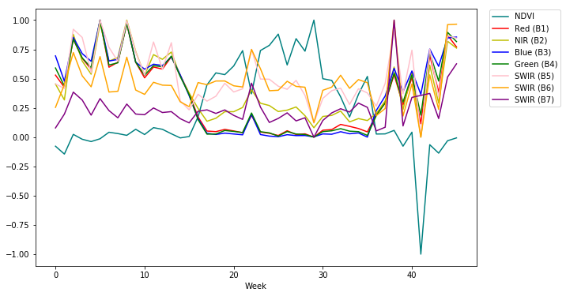

```python
plot_point('box670', 'woody_savannas', 'lat59.61874999469706_lon114.70966591840244.npy')
```

Having written functions to pre-process the data we next explore the trends and characteristics of the dataset at a higher level.

#### Dataset characteristics

As the dataset relates to land coverings across the globe, it would be useful to explore the distribution of the data in terms of countires and land cover types represented.

The metadata shows the latitude/longitude of sampled points, however not the corresponding countries. To analyse the distribution of samples across countires, we look up the country for each region. We use the [Nominatim API](https://nominatim.org/release-docs/develop/api/Overview/), via `geopy`, which provides open-source geocoding with OpenStreetMap data to lookup country names for the coordinates.

```python
# Lookup country for each point in dataset

## Initiate geopy for country lookup
geolocator = Nominatim(user_agent="COMP0173")

def get_country(lat, lon):
    """
    Find the country corresponding to given lat/lon.

    Args:
        lat (float): Latitude.
        lon (float): Longitude.

    Returns:
        country (str): Country corresponding to lat/lon.
    """
    lat_lon = f'{lat}, {lon}'
    # Get address for lat/lon using Nominatim API
    address = geolocator.reverse(lat_lon, language='en').address
    # Country is the last part of the address
    country = address.split(',')[-1].strip()
    return country

## Get list of unique regions in dataset
regions = metadata.box.unique()

## Find and store which country each region is in

region_countires = {}
for region in regions:
    ### Get country for first point in region
    sample_loc = metadata[metadata.box==region].iloc[0]
    lat = sample_loc.lat
    lon = sample_loc.lon
    country = get_country(lat, lon)
    region_countires[region] = country

## Add countries to dataframe
### Since each point is in one region, and each region
### is in one country, we assign all points in a region
### to the same country
metadata['country'] = metadata.box.map(region_countires)

metadata.head()
```

|  | box | landcover | n_samples | filename | fold | lat | lon | metafold | country |
| --- | --- | --- | --- | --- | --- | --- | --- | --- | --- |
| 0 | box670 | deciduous_needleleaf_forests | 98 | lat60.11458332798502_lon114.86058958664744.npy | train | 60.114583 | 114.860590 | train | Russia |
| 1 | box670 | deciduous_needleleaf_forests | 98 | lat60.0354166613256_lon113.9345051911735.npy | train | 60.035417 | 113.934505 | train | Russia |
| 2 | box670 | deciduous_needleleaf_forests | 98 | lat60.13958332798275_lon114.9980869857962.npy | train | 60.139583 | 114.998087 | train | Russia |
| 3 | box670 | deciduous_needleleaf_forests | 98 | lat60.068749994655896_lon114.97653978128507.npy | train | 60.068750 | 114.976540 | train | Russia |
| 4 | box670 | deciduous_needleleaf_forests | 98 | lat60.218749994642174_lon113.63141596589756.npy | train | 60.218750 | 113.631416 | train | Russia |

Now that we have the country each region is in, we can explore some characteristics of the dataset.

```python
n_unique_regions = metadata.box.nunique()
print(f'{"Number of unique region in whole dataset:":44} {n_unique_regions}')

n_unique_countries = metadata.country.nunique()
print(f'Number of unique countries in whole dataset: {n_unique_countries}')
```

```
Number of unique region in whole dataset:    692
Number of unique countries in whole dataset: 103
```

```python
# Define metadata constants
## Extract land cover types
lndcvr_types = metadata.landcover.unique()
## Function to get index of land cover type
get_lndcvr_idx = lambda lndcvr_type: np.where(lndcvr_types==lndcvr_type)[0].item()

train_regions = metadata[metadata.metafold=='train'].box.unique()
val_regions = metadata[metadata.metafold=='val'].box.unique()
test_regions = metadata[metadata.metafold=='test'].box.unique()
```

#### Country Percentages

It would be useful to understand how the data points are distributed by country. In particular, to find out the percentage of points in the dataset by country; we will calculate this below.

```python
# Find count of points in each country
ctry_count = metadata.country.value_counts().reset_index(name='count')
ctry_count.rename(columns = {'index':'country'}, inplace = True)
# Find percentage of points in each country
ctry_count['pct'] = 100*ctry_count['count']/sum(ctry_count['count'])
```

```
Text(0,0.5,'Percentage')
```

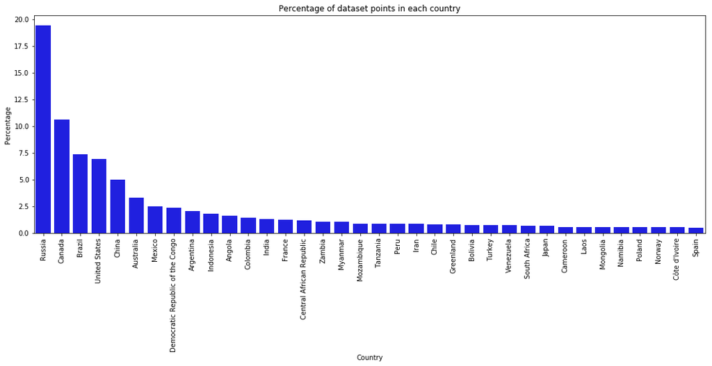

```python
# Consider the countries which contain at least 0.5% of the
# points in the dataset
ctry_count_subset = ctry_count[ctry_count.pct>0.5]
# Plot the percentage of points in these countires
fig, ax = plt.subplots(figsize=(18,6))
sns.barplot(ax=ax, x=ctry_count_subset['country'], y=ctry_count_subset['pct'], color='blue')
plt.xticks(rotation=90)
plt.title('Percentage of dataset points in each country')
plt.xlabel('Country')
plt.ylabel('Percentage')
```

Due to the long tail of the distribution, we restrict the plot above to countries which have at least 0.5% of the points in the dataset. From the plot, we see that the larger countires have a greater proportion of the points in the dataset. This makes sense, as the regions and points in the dataset were initially sampled uniformly at random from across the World, hence points from larger countries are more likely to appear in the dataset.

Next we compare the percentages of the points in each country in the dataset, to the percentages of global land area by country, to see if they are broadly in agreement. We obtained the percentage of global land area by country from [Worldometer](https://www.worldometers.info/geography/largest-countries-in-the-world/) and downloaded the data in an Excel file locally.

```python
# World land area by country (source: https://www.worldometers.info/geography/largest-countries-in-the-world/)
country_land_area = pd.read_excel(os.path.join(ROOT, 'country_land_area.xlsx'))
```

```python
# Calculate percentage of land area for each country
country_land_area['land_area_pct']=100*country_land_area['Land Area(mi²)']/country_land_area['Land Area(mi²)'].sum()
# Sort countries in descending order of percentage land area
country_land_area.sort_values(by='land_area_pct', ascending=False, inplace=True)
```

```
Text(0,0.5,'Percentage')
```

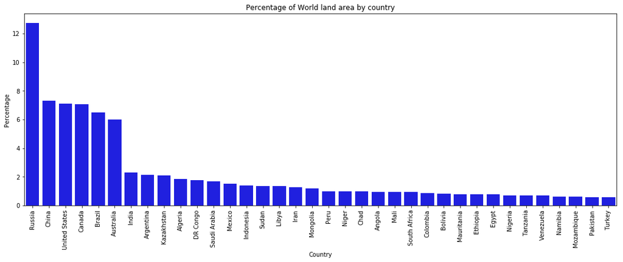

```python
# Plot the 36 countries with greatest land area
# to compare with previous plot
country_land_area_subset = country_land_area[:36]
fig, ax = plt.subplots(figsize=(18,6))
sns.barplot(ax=ax, x=country_land_area_subset['Country'], y=country_land_area_subset['land_area_pct'], color='blue')
plt.xticks(rotation=90)
plt.title('Percentage of World land area by country')
plt.xlabel('Country')
plt.ylabel('Percentage')
```

From the plots above, we see the percentage of points in each country in the dataset, do boradly match the percentage of World land area by country. However, there are a few large decrepencies such as Russia accounting for almost 20% of the dataset, but covering 12.8% of the World's land area (as calculated below). Also, Kazakhstan only represents 0.15% of points in the dataset, even though it has around 2.1% of global land area.

```python
def print_ctry_pcts(country):
    """
    Print the percentage of dataset points in a country, and
    the percentage of global land area in the country.

    Args:
        country (str): Country name.
    """
    dataset_pct = round(ctry_count[ctry_count['country']==country].pct.item(), 2)
    land_area_pct = round(country_land_area_subset[country_land_area_subset.Country==country].land_area_pct.item(),2)
    print(f'Percentage of dataset points in {country}: {dataset_pct}%')
    print(f'Percentage of global land area in {country}: {land_area_pct}%')
```

```python
print_ctry_pcts('Russia')
print_ctry_pcts('Kazakhstan')
```

```
Percentage of dataset points in Russia: 19.4%
Percentage of global land area in Russia: 12.76%
Percentage of dataset points in Kazakhstan: 0.15%
Percentage of global land area in Kazakhstan: 2.1%
```

We do not believe that this imbalance in data is due to an underlying bias in the dataset, but rather an artefact of the data filtering process. The dataset initially sampled 1,000 10kmx10km regions across the Earth, uniformly at random, the dataset was then filtered to remove regions which consisted of only one land cover type, or had one land cover type covering over 80% of the region [1]. This resulted in the 692 regions that have been made available in the final dataset.

The original sample of 1,000 100 km<sup>2</sup> regions is itself small, considering the [Earth's](https://en.wikipedia.org/wiki/Earth) total land area is approximately 148,940,000 km<sup>2</sup>, which means the decrepencies of the type observed above could be due to the uniform sampling method.

This suggests a way the dataset could be improved is to still uniformly sample regions, and in addition ensure the number of regions sampled in each country is proportional to the country's land area on Earth. However, for the puposes of our analysis and model building we will continue with the original dataset.

#### Land cover percentages

Next, we peform a similar analysis of the data but this time from the perspective of the land cover types.

```python
# Count number of points for each land cover type
lndcvr_count = metadata.landcover.value_counts().reset_index(name='count')
# Calculate percentage of dataset for each land cover type
lndcvr_count['pct'] = 100*lndcvr_count['count']/sum(lndcvr_count['count'])
```

```
Text(0,0.5,'Percentage')
```

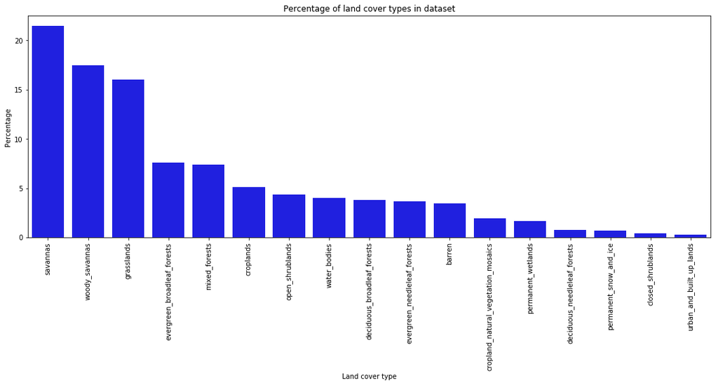

```python
fig, ax = plt.subplots(figsize=(18,6))
sns.barplot(ax=ax, x=lndcvr_count['index'], y=lndcvr_count['pct'], color='blue')
plt.xticks(rotation=90)
plt.title('Percentage of land cover types in dataset')
plt.xlabel('Land cover type')
plt.ylabel('Percentage')
```

From the plot above we observe the data mainly consists of savanna and grassland land covers. This shows there is a class imbalance in our data set, as three of the 17 classes (`savanna`, `woody_svannnas` and `grasslands`) account for over half (55%) of the dataset. We will need to keep this in mind when selecting a metric for ML model evaluation.

#### Country-land cover Pairing Frequencies

We conclude the data exploration by investigating the pairwise proportion of the data by land cover and country.

```
Text(87,0.5,'Country')
```

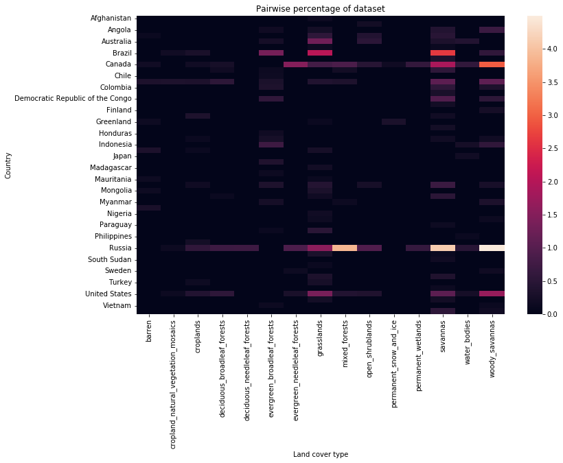

```python
# Create new dataframe with just country and land cover pairing counts
# and take top 144 counts to plot heatmap
ctry_land_counts = metadata[['country', 'landcover']].value_counts().reset_index(name='count')[:144]
# Pivot the dataframe so countries are the indexes and land covers are the columns
ctry_land_counts = ctry_land_counts.pivot(index='country', columns='landcover', values='count')
# Replace NaN with 0s, as NaN appear when country/land cover pair were not observed
ctry_land_counts.fillna(0, inplace=True)

fig, ax = plt.subplots(figsize=(12,8))
# Count of country-land cover as percentage of full dataset
sns.heatmap(100*ctry_land_counts/len(metadata))
ax.set_title('Pairwise percentage of dataset')
ax.set_xlabel("Land cover type")
ax.set_ylabel("Country")
```

From the partial heatmap we see that pairwise counts are sparse, in that most countries have zero or a low proportion of each land cover. We also observe that woody savannas in Russia are the most frequent pairing in the dataset, with just over 4% of the data being in that pairing.

### Task and evaluation (10%)

**Guidelines**: Tell us a bit about the main task that in your view this dataset could help solve and propose and justify the evaluation criteria that would be important here, not only considering the task but your exploratory data analysis. For example, if you found that there is class imbalance in the dataset and that the most important class is the minority one, you may want to add costs in your evaluation metric to account for it, or maybe you want to use a metric specifically suited for imbalanced classification.

**Our discussion**

**Main task:** In our view the main task this dataset can help solve is the land cover classification of geographic points across the World. Specifically, it could be used to develop a model to monitor the change in the Earth's land cover profile over time. The reason for this is that the data consists of wavelength data (captured every 8 days in 2018) on sampled points across the World, along with the land cover type of each point in 2018. It can particularly help with the classification of points in countries with limited resources to perform these classifcations by other means e.g. surveys.

With an increased number of satellites in orbit around Earth, there is a vast amount of aerial images and wavelength timeseries data to support the monitoring of land cover; however the data is often unlabelled and labelling can be a costly task both in time and effort if done manually. As such there is a need to automate the labelling of satellite data which provides information on land coverings, which this dataset is a great source for in the wavelength timeseries case.

**Evaluation criteria:** Since the task is classification based, one metric we could use is accuracy. However, as we have seen during data exploration there is a class imbalance in our data, with `savannas` accounting for over 20% of the dataset. Hence, even with the static classifier that always predicts `savannas` we could achieve an accuracy over 20%, which would appear to be better than a random classifier that could achieve ~6% (1/17) accuracy, but is not a useful classifier.

A metric which takes class imbalance into account is the F1 score which is the harmonic mean of precision and recall, this is a useful metric for our task given our dataset. However, the standard setting for the F1 socre is the binary classification task whereas we are considering a 17-way classification. As such, we note that in calculating the F1 score for our task we will in effect be calculting the F1 score for each class versus the rest, to obtain 17 F1 scores, and then average these to obtain a single F1 score for model comparison. There are two ways we could average the scores, one is the unweighted mean and one weighted by the number of true instances for each class. These are referred to as `macro` and `weighted` respectively in the `sklearn.metrics.f1_score` function, which is the function we will use for calculating the F1 score. Since we want our classifier to be evaluated on classification taking into account the land cover type imbalance, we decide to use the `weighted` method of averaging.

Finally we will also evaluate our models using Cohen's kappa score [5], as this is the final metric used by Wang et al. [1] and will allow us to make a comparison with the previous work on this dataset. The kappa statistic gives a score that expresses the level of agreement between two annotators on a classification problem. The score is thought to be more robust than a simple percent agreement calculation, as kappa takes into account the possibility of the agreement occurring by chance. We refer the reader to [5] and [Wikipedia](https://en.wikipedia.org/wiki/Cohen%27s_kappa) for more details on Cohen's kappa score. We will be using scikit-learn's `sklearn.metrics.cohen_kappa_score` function to calculate the score.

We note, while Wang et al. [1] make use of all three metrics, they apply them to 1-shot 2-way classification tasks, whilst we will be applying them to a 17-way classification task. Therefore the F1 and kappas scores may not be directly comparable, however we may able to compare them at a high level to see if they are in a similar range.

### Design and build an ML system (20%)

**Guidelines**: Taking into account the task and evaluation criteria set in the previous section design and build now an ML system. If you go for supervised learning, you could start by partiting your dataset in train and test here and try a model on the dataset. But please justify your choices in each case. Why did you choose a specific ML model? Why is it relevant for the task and dataset at hand? Do you envision any challenges with the use of such model?

Again, we do not ask for a specific model to be used. Instead, we will evaluate the depth and appropriatedness of your analysis. As this section (and some of the following ones) are more open ended we do not specify marks for each question.

Please note that if the dataset of your choice is too large to work with, you can simply choose a subset of it. We will not substract any marks for doing so.

**Our discussion**

#### Baseline model

Given each sample in the dataset consists of eight timeseries and a label, we choose to use a **1D Convolutional Neural Network** (CNN), as our underlying model. Specifically, we choose a CNN approach as the architecture has been shown to perform well for multivariate time series classification [4], moreover it is also the architecture used by Wang et al. [1] allowing us to comapre our results to those from the earlier work. For these reasons we believe a CNN would be a relevant and well-suited model for our task.

One of the challenges with neural networks is that they can overfit to the data they are trained on, to avoid this we will include dropout layers in our network architecture.

**Novelty**

Since the task at hand is a classification task, we will use a supervised learning approach. One of the main aspects of the task is to be able to make land cover classifications using relatively low volumes of data. Wang et al. address this by using a Meta-learning approach, which require only a few shots in each test region for fine-tuning their meta-learned model for that region.

We also aim to reduce the amount of data we need to make classifications, however where Wang et al. compare the performance of Meta-learning, Transfer Learning and training from scratch on each region *keeping the dataset fixed*, we are interested in keeping the training method fixed and *reducing the size of the training dataset*.

Specifically, we will take a [Transfer Learning](https://en.wikipedia.org/wiki/Transfer_learning) approach to the task and pre-train a CNN on data from high-resource countries and fine-tune the model for each Sub-Saharan country in the test set. We will perform the pre-training in two ways to test the following hypothesis.

**Hypothesis:**

> The fine-tuned models based on the data from countries within the same [climate zone](https://en.wikipedia.org/wiki/Köppen_climate_classification) as the test countries, will on average out-perform the fine-tuned models based on data from countries with the most points in the dataset, but are not necessarily in the same climate zone.

Our reason for proposing this hypothesis is that the same land cover type may look different in different regions of the World. One of the main natural factors that can affect land cover is climate, as such the wavelength measurements of the same land cover type in countries which are in the same climate zones may be very similar, but could differ in countires with different climate zones.

If the results of our experiment are promising, this may suggest another approach for reducing the amount of data needed to train such a classificaiton model. Since, it suggests if we have limited resource to gather training data, we can do so systematically by focussing on high-resource countries within the same climate zone as the low-resource countires.

To test our hypothesis we use the following experiment structure.

**Experiment:**

1. Create a dev set consisting of countries with a high proportion of points (i.e. at least 2.5%) in the dataset
2. Pre-train a CNN using this dev set
3. Fine-tune the model on each of the Sub-Saharan test countries' data points
4. Calculate the average accuracy, F1 and kappa score on the test points for the Sub-Saharan countries, using the relevant fine-tuned models
5. Create a dev set consisting of countries within the same climate zone as the Sub-Saharn countries, namely the [Tropic Zone](https://en.wikipedia.org/wiki/Tropics) (this dataset will have fewer points than the baseline dev set from 1.)
6. Repeat steps 2-4 using this second dev set
7. Compare the results of the two approaches

We begin our model development by writing a function to split a given dataset into a train and test set.

```python
def train_test_dataset(dataset, test_split=0.2, shuffle=True):
    """
    Split PyTorch dataset into a train and test set.

    Args:
        dataset (Dataset): Dataset to be split.
        test_split (float): Portion of data to be allocated to test set,
        default=0.2.
        shuffle (bool): Shuffles dataset before splitting if True,
        default=True.

    Returns:
        train_set (Subset): Training data set.
        test_set (Subset): Test data set.
    """
    train_idx, test_idx = train_test_split(list(range(len(dataset))), test_size=test_split, shuffle=shuffle)
    return Subset(dataset, train_idx), Subset(dataset, test_idx)
```

Rather than load the entire dataset into memory, we will retrieve the data for each point as we need it during training. Since the location on disk of the data for each point comes from the metadata CSV, we design a custom PyTorch Dataset to join the elements of the data filepath and then load the data in from disk.

```python
class CustomDataset(Dataset):
    """
    Custom PyTorch Dataset for Out-of-Domain Land Cover data.
    """
    def __init__(self, metadata, transform=None, target_transform=None):
        # Initialise Dataset with the relevant metadata
        self.metadata = metadata
        self.transform = transform
        self.target_transform = target_transform

    def __len__(self):
        return len(self.metadata)

    def __getitem__(self, idx):
        # Get metadata for point in dataset
        region, lndcvr_type, fname = self.metadata.iloc[idx][['box', 'landcover', 'filename']]
        # Join these elements to form the file path where the point's data is located
        point_path = os.path.join(MODIS_FPATH, region, lndcvr_type, fname)
        # Load the data in, performing standardisation and interpolation of NaNs
        point_data = load_point(point_path)
        # Get index of land cover label
        label = get_lndcvr_idx(lndcvr_type)
        # Option for additional transforms if needed
        if self.transform:
            point_data = self.transform(point_data)
        if self.target_transform:
            label = self.target_transform(label)
        # Return point data and corresponding label
        return point_data, label
```

Next, we define our 1D Convolutional Neural Network. Since we are mainly concerned with exploring the effect on performance by reducing the training dataset size, for a fixed model architecture and hyper-parameters, rather than obtaining state-of-the-art performance on this dataset we develop a small CNN architecture. As such, we build a CNN with four convolutional layers and two fully connected layers.

We have set the kernel size to 4, this was based on hyper-parameter tuning which we discuss in the next section. Moreover, we also include an `ablated` flag which we allows us to perform an ablation study investigating the effect of removing the fully connected layers from our network. This is also described in more detail in the next section.

```python
class TimeSeriesCnnModel(nn.Module):
    """
    1D Convolutional Neural Network.
    """
    def __init__(self, kernel_size=4, ablated=False):
        super().__init__()
        self.kernel_size = kernel_size
        self.ablated = ablated
        self.convs = nn.Sequential(
            nn.Conv1d(8, 16, kernel_size=self.kernel_size, stride=2, padding=2),
            nn.ReLU(), nn.Dropout(0.2),
            nn.Conv1d(16, 32, kernel_size=self.kernel_size, stride=2, padding=2),
            nn.ReLU(), nn.Dropout(0.2),
            nn.MaxPool1d(2), # output: 64 x 23

            nn.Conv1d(32, 64, kernel_size=self.kernel_size, stride=2, padding=2),
            nn.ReLU(), nn.Dropout(0.2),
            nn.Conv1d(64, 128, kernel_size=self.kernel_size, stride=2, padding=2),
            nn.ReLU(), nn.Dropout(0.2),
            nn.MaxPool1d(2), # output: 128
        )

        layers = list(self.convs.children())

        # Remove fully connected layers for ablated version of network.
        # This is discussed in the Experimental Analysis section.
        if self.ablated:
            layers.extend([nn.Flatten(), nn.Linear(128, 17)])
        else:
            fc_layers = nn.Sequential(
                nn.Flatten(),
                nn.Dropout(0.4), nn.Linear(128, 512), nn.ReLU(),
                nn.Dropout(0.4), nn.Linear(512, 256), nn.ReLU(),
                nn.Linear(256, 17) # output: 17 (number of land cover types)
            )
            layers.extend(list(fc_layers.children()))
        self.network = nn.Sequential (*layers)

    def forward(self, x):
        out = self.network(x)
        return out
```

```python
# Detect if we have a GPU available
device = torch.device("cuda:0" if torch.cuda.is_available() else "cpu")
```

```python
# In our case we only have access to a CPU
device
```

```
device(type='cpu')
```

Now that we have designed the model, we write a wrapper function to train the CNN given a training and validation set.

While we will evaluate our trained model on three metrics, as discussed above, during training we will just report the train and val accuracy for simplicity in monitoring training performance. In particular, by monitoring the validation accuracy we can check if we are beginning to overfit to the training data.

Similarly, we also report the training and validation loss for this purpose. We choose to use the Cross Entropy loss for training, as it is a widely used loss function for classificaiton tasks and relevant for our task.

```python
def train(train_set, val_set, model=None, n_epochs=10, batch_size=16, kernel_size=4,
          lr=0.001, shuffle=True, print_freq=2, ablated=False):
    """
    Network training wrapper.
    """
    since = time.time()

    train_loader = DataLoader(train_set, batch_size=batch_size, shuffle=shuffle, num_workers=0)
    val_loader = DataLoader(val_set, batch_size=batch_size, shuffle=shuffle, num_workers=0)

    dataloaders = {'train': train_loader, 'val': val_loader}

    # Initialise model if one is not provided
    if model is None:
        model = TimeSeriesCnnModel(kernel_size=kernel_size, ablated=ablated)
    model = model.to(device)

    # Lists to record loss and accuracy history
    train_loss_history, val_loss_history = [], []
    train_acc_history, val_acc_history = [], []

    # Initialise best network weights and accuracy
    best_model_wts = copy.deepcopy(model.state_dict())
    best_acc = 0.0

    # Set loss function and optimiser
    criterion = torch.nn.CrossEntropyLoss()
    optimizer = optim.Adam(model.parameters(), lr=lr)

    for epoch in trange(n_epochs, desc='Epoch'):  # Loop over the dataset multiple times

        epoch_str = '{:5}'.format(f'{epoch+1}/{n_epochs}') # Used when printing stats
        running_loss = 0.0

        for phase in ['train', 'val']:
            if phase=='train':
                model.train() # Set model to train mode
            else:
                model.eval() # Set model to evaluate mode

            running_loss = 0.0
            running_corrects = 0

            for i, data in enumerate(dataloaders[phase]):

                # Get the inputs; data is a tuple (inputs, labels)
                inputs, labels = data
                inputs = inputs.to(device)
                labels = labels.to(device)

                # Zero the parameter gradients
                optimizer.zero_grad()

                # Forward
                with torch.set_grad_enabled(phase=='train'):
                    outputs = model(inputs.float())
                    loss = criterion(outputs, labels)

                    _, preds = torch.max(outputs, 1)

                    # Backward + optimize if in train mode
                    if phase=='train':
                        loss.backward()
                        optimizer.step()

                # Print training statistics
                running_loss += loss.item() * inputs.size(0)
                running_corrects += torch.sum(preds == labels.data)

            # Statistics
            epoch_loss = running_loss / len(dataloaders[phase].dataset)
            epoch_acc = running_corrects.double() / len(dataloaders[phase].dataset)

            if (print_freq is not None) and (epoch%print_freq == print_freq-1):
                print(f'\t{BOLD}{CYAN}Epoch: {epoch_str} | {phase} Loss: {epoch_loss:.4f} |\
                Accuracy: {100*epoch_acc:.2f}%{ENDC}')

            # Deep copy the model
            if phase == 'val' and epoch_acc > best_acc:
                best_acc = epoch_acc
                best_model_wts = copy.deepcopy(model.state_dict())
            if phase == 'train':
                train_loss_history.append(epoch_loss)
                train_acc_history.append(epoch_acc.item())
            else:
                val_loss_history.append(epoch_loss)
                val_acc_history.append(epoch_acc.item())

    stats = {'train_loss_history': train_loss_history,
            'train_acc_history': train_acc_history,
            'val_loss_history': val_loss_history,
            'val_acc_history': val_acc_history}

    print(f'{BOLD}Training finished.{ENDC}')
    time_elapsed = time.time() - since
    print('Training complete in {:.0f}m {:.0f}s'.format(time_elapsed // 60, time_elapsed % 60))
    print('Best val Acc: {:4f}'.format(best_acc))

    # Load best model weights
    model.load_state_dict(best_model_wts)
    return model, stats
```

```python
def save_model(model, fpath):
    """
    Save trained model to given file location.
    """
    torch.save(model.state_dict(), fpath)
    print(f'Model saved to: {fpath}')
```

```python
def evaluate(testset, model, batch_size=32):
    """
    Evaluate a model using a given testset. The model
    will be evaluated on three metrics: accuracy, F1 and
    kappa score.
    """
    model = model.to(device)
    testloader = DataLoader(testset, batch_size=batch_size, shuffle=False, num_workers=0)

    # Initialise lists to store true labels and predictions
    ground_truth = []
    predictions = []

    for test_data in testloader:
        # Get test timeseries data and true labels
        test_timeseries, true_labels = test_data
        test_timeseries = test_timeseries.to(device)
        true_labels = true_labels.to(device)

        # Perform inference
        outputs = model(test_timeseries.float())
        _, preds = torch.max(outputs, 1)
        # Append predictions and true labels
        predictions.append(preds)
        ground_truth.append(true_labels)

    # Concatenate the torch tensors for true labels into a single tensor,
    # and the same for the prediction tensors
    ground_truth = torch.cat(ground_truth)
    predictions = torch.cat(predictions)

    # Calculate metrics
    accuracy = metrics.accuracy_score(ground_truth, predictions)
    f1 = metrics.f1_score(ground_truth, predictions, average='weighted')
    kappa = metrics.cohen_kappa_score(ground_truth, predictions)

    return accuracy, f1, kappa
```

Now that we have defined our model, training loop and evaluation, we begin our experiment. We begin by pre-training a baseline model using the non-test countries. Due to the size of the data set and our compute resource, rather than use all the non-test countries, we restrict ourselves to the countries each with at least 2.5% of the data. This still amounts to over half (55%) of the dataset, as calculated below.

```python
# Countries with over 2.5% of the points in the dataset
over_2pt5_pct_ctrys = ctry_count[ctry_count.pct>2.5]
over_2pt5_pct_ctrys
```

|  | country | count | pct |
| --- | --- | --- | --- |
| 0 | Russia | 64813 | 19.404567 |
| 1 | Canada | 35499 | 10.628157 |
| 2 | Brazil | 24705 | 7.396507 |
| 3 | United States | 23240 | 6.957896 |
| 4 | China | 16616 | 4.974716 |
| 5 | Australia | 11063 | 3.312186 |
| 6 | Mexico | 8387 | 2.511010 |

```python
print(f'{BOLD}Combined stats for the six countires with over 2.5% of the points in the dataset:{ENDC}')
print(f'Total samples: {over_2pt5_pct_ctrys["count"].sum():,}')
print(f'Total percentage: {over_2pt5_pct_ctrys.pct.sum():.2f}%')
```

[output not shown]

```python
# Get metadata for these countries
pt_metadata = metadata[(metadata.country.isin(over_2pt5_pct_ctrys.country))]
# Instantiate baseline dataset
pt_ds = CustomDataset(metadata=pt_metadata)
# Split the data into a train and validation set
pt_train_ds, pt_val_ds = train_test_dataset(pt_ds)
```

We can now begin pre-training our baseline model, we choose to train the model for 15 epochs as we only have access to a CPU. With access to a GPU we would use a larger number of training epochs, and monitor the validation accuracy and loss to decide if we need to stop training early, e.g. due to overfitting to the training data.

```python
# Pretrain baseline model and get stats for training
pt_model, pt_stats = train(pt_train_ds, pt_val_ds, n_epochs=15, batch_size=32)
```

```
	Epoch: 2/15  | train Loss: 1.2867 | Accuracy: 52.25%
	Epoch: 2/15  | val Loss: 1.1300 | Accuracy: 57.85%
	Epoch: 4/15  | train Loss: 1.2115 | Accuracy: 54.85%
	Epoch: 4/15  | val Loss: 1.1040 | Accuracy: 59.41%
	Epoch: 6/15  | train Loss: 1.1836 | Accuracy: 55.83%
	Epoch: 6/15  | val Loss: 1.0666 | Accuracy: 60.41%
	Epoch: 8/15  | train Loss: 1.1666 | Accuracy: 56.39%
	Epoch: 8/15  | val Loss: 1.0397 | Accuracy: 61.03%
	Epoch: 10/15 | train Loss: 1.1552 | Accuracy: 56.81%
	Epoch: 10/15 | val Loss: 1.0427 | Accuracy: 61.31%
	Epoch: 12/15 | train Loss: 1.1510 | Accuracy: 57.10%
	Epoch: 12/15 | val Loss: 1.0415 | Accuracy: 60.79%
	Epoch: 14/15 | train Loss: 1.1433 | Accuracy: 57.51%
	Epoch: 14/15 | val Loss: 1.0284 | Accuracy: 62.12%

Training finished.
Training complete in 78m 21s
Best val Acc: 0.621213
```

Having pre-trained the first baseline model, we save the model and its training results.

```python
# Check if trained_models folder exists, create if not
trained_models_fpath = os.path.join(ROOT, 'trained_models')

if not os.path.exists(trained_models_fpath):
    os.mkdir(trained_models_fpath)

# Save pretrained baseline model
baseline_model_path = os.path.join(trained_models_fpath, 'baseline_pt_model.pt')
save_model(pt_model, baseline_model_path)
```

```
Model saved to: ./trained_models/baseline_pt_model.pt
```

```python
# Check if results folder exists, create if not
results_fpath = os.path.join(ROOT, 'results')

if not os.path.exists(results_fpath):
    os.mkdir(results_fpath)

# Save pretrained baseline models stats
baseline_results_path = os.path.join(results_fpath, 'baseline_pt_results.json')
with open(baseline_results_path, 'w') as f:
    json.dump(pt_stats, f, indent=2)
```

```python
def plot_stats(stats):
    """
    Plot training stats
    """
    fig, axs = plt.subplots(1, 2, figsize=(16, 5))

    train_loss_hist = stats['train_loss_history']
    val_loss_hist = stats['val_loss_history']
    loss_data = np.array([train_loss_hist, val_loss_hist]).T

    train_acc_hist = stats['train_acc_history']
    val_acc_hist = stats['val_acc_history']
    acc_data = np.array([train_acc_hist, val_acc_hist]).T

    sns.lineplot(ax=axs[0], data=loss_data, dashes=False, legend=False)
    axs[0].set_xlabel('Epoch')
    axs[0].set_ylabel('Loss')

    sns.lineplot(ax=axs[1], data=acc_data, dashes=False, legend=False)
    axs[1].set_xlabel('Epoch')
    axs[1].set_ylabel('Accuracy')

    fig.legend(['Train', 'Validation'], loc='lower center', ncol=2)
```

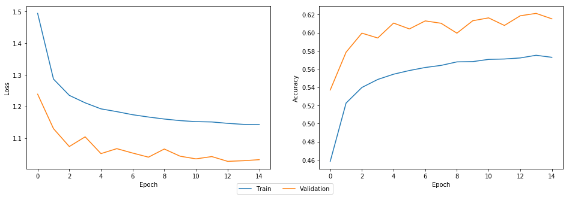

```python
plot_stats(pt_stats)
```

From the plots above we can see both the train and validation loss decrease as the number of epochs increases. Likewise the both the train and validation accuracies are broadly increasing with the number of epochs. This suggests the model is learning well, and we are not seeing signs of overfitting.

However, we do note the validation loss is below the training loss and its accuracy is greater than the training accuracy. The reason for this is because we use droput layers, for regularisation, in our model which apply during training, but not during inference which is when we calculate the validation loss and accuracy. If we were to add the regularisation loss to the validation loss we would likely see it slightly above the training loss.

#### Tropic Zone pre-training

Having trained a baseline model with over 55% of the dataset, we now pre-train another model but this time one based on countries in the same climate zone as our test countries, which are located in Sub-Saharan Africa. The majority of the Sub-Saharan countires are within the [Tropic Zone](https://en.wikipedia.org/wiki/Tropics), and so we select training data from countries in this region to pre-train our second model.

#### Tropic Zone

The Tropic Zone is the region south of the Tropic of Cancer (latitude 23.4364° N) and north of the Tropic of Capricorn (latitude 23.4364° S), which is shaded in the figure below.

[figure not shown]

Source: [Wikipedia](https://commons.wikimedia.org/w/index.php?curid=27385077)

```python
# Approximate lat bounds for Tropic Zone
lat_sound_bound, lat_north_bound = -23.4, 23.4 #(Approx. Tropic of Capricorn and Tropic of Cancer respectively)
```

```python
# Filters to find Tropic Zone countires, based on latitude bounds
# defined in previous cell. Also, ensure we exclude the test countires themselves
tz_filters = (metadata.lat<lat_north_bound) & (metadata.lat>lat_sound_bound) & (metadata.metafold!='test')
tz_metadata = metadata[tz_filters]
```

```python
print(f'{BOLD}Size of Tropic Zone training dataset:{ENDC}')
print(f'Total samples: {len(tz_metadata):,}')
print(f'Percentage of Baseline dataset: {100*len(tz_metadata)/len(pt_metadata):.2f}%')
print(f'Percentage of full dataset: {100*len(tz_metadata)/len(metadata):.2f}%')
```

```
Size of Tropic Zone training dataset:
Total samples: 68,019
Percentage of Baseline dataset: 36.90%
Percentage of full dataset: 20.36%
```

From the figures above we see that this second pre-training dataset is approximately 37% the size of the initial baseline dataset we considered. Moreover, it is 20% of the full dataset, so it is relatively small compared to both.

We now pre-train a model using this Tropic Zone dataset.

```python
tz_ds = CustomDataset(metadata=tz_metadata)
tz_train_ds, tz_val_ds = train_test_dataset(tz_ds)
```

```python
# Pretrain Tropic Zone model and get stats for training
tz_model, tz_stats = train(tz_train_ds, tz_val_ds, n_epochs=15, batch_size=32)
```

```
	Epoch: 2/15  | train Loss: 1.1385 | Accuracy: 57.65%
	Epoch: 2/15  | val Loss: 1.0595 | Accuracy: 60.29%
	Epoch: 4/15  | train Loss: 1.0612 | Accuracy: 60.47%
	Epoch: 4/15  | val Loss: 1.0137 | Accuracy: 60.95%
	Epoch: 6/15  | train Loss: 1.0259 | Accuracy: 61.37%
	Epoch: 6/15  | val Loss: 0.9760 | Accuracy: 61.84%
	Epoch: 8/15  | train Loss: 1.0077 | Accuracy: 62.51%
	Epoch: 8/15  | val Loss: 0.9400 | Accuracy: 64.63%
	Epoch: 10/15 | train Loss: 0.9901 | Accuracy: 62.81%
	Epoch: 10/15 | val Loss: 0.9617 | Accuracy: 64.82%
	Epoch: 12/15 | train Loss: 0.9806 | Accuracy: 63.23%
	Epoch: 12/15 | val Loss: 0.9563 | Accuracy: 63.07%
	Epoch: 14/15 | train Loss: 0.9671 | Accuracy: 63.73%
	Epoch: 14/15 | val Loss: 0.9545 | Accuracy: 65.19%

Training finished.
Training complete in 31m 56s
Best val Acc: 0.656645
```

```python
# Save pretrained Tropic Zone model
tz_model_path = os.path.join(trained_models_fpath, 'tz_pt_model.pt')
save_model(tz_model, tz_model_path)

# Save pretrained models stats
tz_results_path = os.path.join(results_fpath, 'tz_pt_results.json')
with open(tz_results_path, 'w') as f:
    json.dump(tz_stats, f, indent=2)
```

```
Model saved to: ./trained_models/tz_pt_model.pt
```

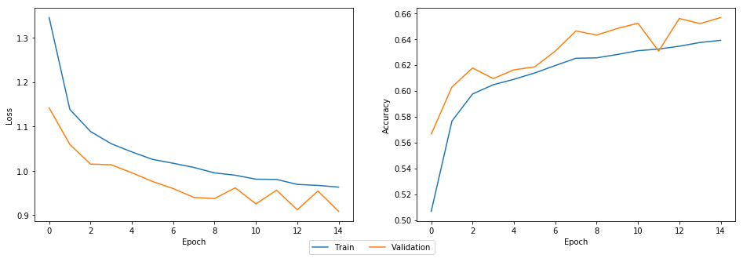

```python
plot_stats(tz_stats)
```

Again, plotting the training statistics we can see the model is training well, and we cannot see signs of overfitting. Both the training and validation loss are decreasing overall with epochs, while the accuracies are increasing.

We also see the same behaviour of validation loss being lower than training and having higher accuracy, this is again due to the regularisation effect of the dropout layers during training.

Lastly we note the Tropic Zone model completed training in 31 minutes, which is less than half the time required by our first baseline model, which took 1 hour and 18 minutes to train.

### Experimental analysis (performance & scalability) (20%)

**Guidelines**: Test your model here. You can do hyper-parameter tuning and any ablation studies you consider important. How does your model perform? Is there any room for improvement? If so, what do you think it's needed? Comment as well on how does the model compare to previous baselines. Do you think model's performance is enough for the application that you are aiming to address? Is the model scalable to a real-world application? Is training data enough for such an application? How does the model's performance compare to a more/less computationally heavy model? Some of these questions may be more or less relevant depending on your application, so we leave it up to you to decide which factors in terms of performance and scalability you consider most important to evaluate.

**Our discussion**

#### Fine-tuning and testing

Now that we have pre-trained two models, we compare their performance by fine-tuning both models for each test country in Sub-Saharan Africa and calculating the average accuracy, F1 and kappa scores achieved by the fine-tuned models, based on the two different pre-trained models.

We note that each test country has on average ~850 training points, as calculated below. However, viewing the histogram below we actually see most countries have between 250-750 test points, with two outliers having ~2,700 and ~4,000 training points which increase the overall average. Hence fine-tuning for each test country should be relatively quick.

```python
train_pts_test_ctrys = metadata[(metadata.metafold=='test') & (metadata.fold=='train')]
train_pt_count = pd.DataFrame(train_pts_test_ctrys.groupby('country').landcover.count())
avg_train_pts_test_ctry = train_pt_count.landcover.mean()
print(f'Average number of training points for each test country: {avg_train_pts_test_ctry:.2f}')
```

```
Average number of training points for each test country: 852.57
```

```
Text(0,0.5,'Country count')
```

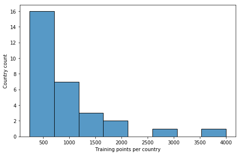

```python
fig, ax = plt.subplots(1, 1, figsize=(8, 5))
sns.histplot(train_pt_count, x='landcover', ax=ax)
ax.set_xlabel('Training points per country')
ax.set_ylabel('Country count')
```

```python
def ft_ctry_model(country, pt_model_path, n_epochs=15, batch_size=32, print_freq=None):
    """
    Fine-tune the pre-trained model for a given country.

    Args:
        country (str): Country to fine-tune pre-trained model for.
        pt_model_path (str): File path to pre-trained model.
        n_epochs (int): Number of epochs to fine-tune model for,
        default=15.
        batch_size (int): Batch size to use during fine-tuning,
        default=32.
        print_freq (int or None): Epoch frequency with which to print
        training stats, default=None (i.e. does not print stats).

    Returns:
        ft_model (TimeSeriesCnnModel): Fine-tuned model.
        ft_stats (dict): Dictionary of training statistics.
    """
    # Initialise fine-tuned model
    ft_model = TimeSeriesCnnModel()
    # Initialise parameters to pretrained model parameters
    ft_model.load_state_dict(torch.load(pt_model_path))

    # Get data for fine-tuning
    train_metadata = metadata[(metadata.country==country) & (metadata.fold=='train')]
    test_metadata = metadata[(metadata.country==country) & (metadata.fold=='test')]
    train_ds = CustomDataset(metadata=train_metadata)
    test_ds = CustomDataset(metadata=test_metadata)

    # Fine-tune model and get stats for training
    ft_model, ft_stats = train(train_ds, test_ds, model=ft_model, n_epochs=n_epochs,
                               batch_size=batch_size, print_freq=print_freq)
    ft_eval = evaluate(test_ds, ft_model)
    return ft_model, ft_eval
```

```python
def fine_tuning(pt_model_path):
    """
    Perform fine-tuning on all test countries, using the pre-trained
    model located at 'pt_model_path', and store the evaluation metrics
    for each.
    """
    test_countries = sorted(metadata[metadata.metafold=='test'].country.unique())
    test_country_stats = {}

    for i in trange(len(test_countries)):
        test_country = test_countries[i]
        print(f'Fine-tuning for: {test_country}')
        fname = ''.join(e for e in test_country if e.isalnum())
        ft_model, ft_eval = ft_ctry_model(test_country, pt_model_path)
        test_country_stats[test_country] = ft_eval
    return test_country_stats
```

We first perform fine-tuning using the Baseline pre-trained model.

```python
# Fine-tune a model for each test country, using the Baseline pre-trained model
baseline_ft_results = fine_tuning(baseline_model_path)
```

```
Fine-tuning for: Angola
```

```
Training finished.
Training complete in 2m 13s
Best val Acc: 0.665320
Fine-tuning for: Benin
```

```
Training finished.
Training complete in 0m 12s
Best val Acc: 0.711864
Fine-tuning for: Botswana
```

```
Training finished.
Training complete in 0m 12s
Best val Acc: 0.659919
Fine-tuning for: Cameroon
```

```
Training finished.
Training complete in 0m 48s
Best val Acc: 0.778116
Fine-tuning for: Central African Republic
```

```
Training finished.
Training complete in 1m 37s
Best val Acc: 0.611307
Fine-tuning for: Congo-Brazzaville
```

```
Training finished.
Training complete in 0m 12s
Best val Acc: 0.619835
Fine-tuning for: Côte d'Ivoire
```

```
Training finished.
Training complete in 0m 45s
Best val Acc: 0.683640
Fine-tuning for: Democratic Republic of the Congo
```

```
Training finished.
Training complete in 3m 11s
Best val Acc: 0.691705
Fine-tuning for: Eswatini
```

```
Training finished.
Training complete in 0m 12s
Best val Acc: 0.670732
Fine-tuning for: Ethiopia
```

```
Training finished.
Training complete in 0m 39s
Best val Acc: 0.742240
Fine-tuning for: Gabon
```

```
Training finished.
Training complete in 0m 12s
Best val Acc: 0.774194
Fine-tuning for: Guinea
```

```
Training finished.
Training complete in 0m 36s
Best val Acc: 0.758108
Fine-tuning for: Kenya
```

```
Training finished.
Training complete in 0m 12s
Best val Acc: 0.647773
Fine-tuning for: Madagascar
```

```
Training finished.
Training complete in 0m 34s
Best val Acc: 0.812587
Fine-tuning for: Malawi
```

```
Training finished.
Training complete in 0m 12s
Best val Acc: 0.795918
Fine-tuning for: Mali
```

```
Training finished.
Training complete in 0m 12s
Best val Acc: 0.696721
Fine-tuning for: Mauritania
```

```
Training finished.
Training complete in 0m 24s
Best val Acc: 0.786151
Fine-tuning for: Mozambique
```

```
Training finished.
Training complete in 1m 12s
Best val Acc: 0.678378
Fine-tuning for: Namibia
```

```
Training finished.
Training complete in 0m 48s
Best val Acc: 0.725331
Fine-tuning for: Niger
```

```
Training finished.
Training complete in 0m 12s
Best val Acc: 0.778226
Fine-tuning for: Nigeria
```

```
Training finished.
Training complete in 0m 36s
Best val Acc: 0.628880
Fine-tuning for: Somalia
```

```
Training finished.
Training complete in 0m 24s
Best val Acc: 0.690141
Fine-tuning for: South Africa
```

```
Training finished.
Training complete in 0m 58s
Best val Acc: 0.612468
Fine-tuning for: South Sudan
```

```
Training finished.
Training complete in 0m 24s
Best val Acc: 0.765182
Fine-tuning for: Sudan
```

```
Training finished.
Training complete in 0m 19s
Best val Acc: 0.862338
Fine-tuning for: Tanzania
```

```
Training finished.
Training complete in 1m 12s
Best val Acc: 0.725981
Fine-tuning for: Togo
```

```
Training finished.
Training complete in 0m 12s
Best val Acc: 0.770833
Fine-tuning for: Uganda
```

```
Training finished.
Training complete in 0m 24s
Best val Acc: 0.633603
Fine-tuning for: Zambia
```

```
Training finished.
Training complete in 1m 23s
Best val Acc: 0.681109
Fine-tuning for: Zimbabwe
```

```
Training finished.
Training complete in 0m 12s
Best val Acc: 0.552846
```

```python
# Save Baseline fine-tuned model stats
baseline_ft_results_path = os.path.join(results_fpath, 'baseline_ft_results.json')
with open(baseline_ft_results_path, 'w') as f:
    json.dump(baseline_ft_results, f, indent=2)
```

Next, we fine-tune using the Tropic Zone pre-trained model.

```python
# Fine-tune a model for each test country, using the Tropic Zone pre-trained model
tz_ft_results = fine_tuning(tz_model_path)
```

```
Fine-tuning for: Angola
```

```
Training finished.
Training complete in 2m 13s
Best val Acc: 0.672667
Fine-tuning for: Benin
```

```
Training finished.
Training complete in 0m 12s
Best val Acc: 0.724576
Fine-tuning for: Botswana
```

```
Training finished.
Training complete in 0m 12s
Best val Acc: 0.643725
Fine-tuning for: Cameroon
```

```
Training finished.
Training complete in 0m 46s
Best val Acc: 0.779129
Fine-tuning for: Central African Republic
```

```
Training finished.
Training complete in 1m 33s
Best val Acc: 0.601212
Fine-tuning for: Congo-Brazzaville
```

```
Training finished.
Training complete in 0m 12s
Best val Acc: 0.652893
Fine-tuning for: Côte d'Ivoire
```

```
Training finished.
Training complete in 0m 43s
Best val Acc: 0.694475
Fine-tuning for: Democratic Republic of the Congo
```

```
Training finished.
Training complete in 3m 1s
Best val Acc: 0.702074
Fine-tuning for: Eswatini
```

```
Training finished.
Training complete in 0m 12s
Best val Acc: 0.703252
Fine-tuning for: Ethiopia
```

```
Training finished.
Training complete in 0m 35s
Best val Acc: 0.747638
Fine-tuning for: Gabon
```

```
Training finished.
Training complete in 0m 12s
Best val Acc: 0.774194
Fine-tuning for: Guinea
```

```
Training finished.
Training complete in 0m 35s
Best val Acc: 0.772973
Fine-tuning for: Kenya
```

```
Training finished.
Training complete in 0m 12s
Best val Acc: 0.651822
Fine-tuning for: Madagascar
```

```
Training finished.
Training complete in 0m 33s
Best val Acc: 0.813986
Fine-tuning for: Malawi
```

```
Training finished.
Training complete in 0m 13s
Best val Acc: 0.808163
Fine-tuning for: Mali
```

```
Training finished.
Training complete in 0m 12s
Best val Acc: 0.680328
Fine-tuning for: Mauritania
```

```
Training finished.
Training complete in 0m 23s
Best val Acc: 0.806517
Fine-tuning for: Mozambique
```

```
Training finished.
Training complete in 1m 10s
Best val Acc: 0.707432
Fine-tuning for: Namibia
```

```
Training finished.
Training complete in 0m 45s
Best val Acc: 0.743642
Fine-tuning for: Niger
```

```
Training finished.
Training complete in 0m 12s
Best val Acc: 0.790323
Fine-tuning for: Nigeria
```

```
Training finished.
Training complete in 0m 34s
Best val Acc: 0.635628
Fine-tuning for: Somalia
```

```
Training finished.
Training complete in 0m 23s
Best val Acc: 0.732394
Fine-tuning for: South Africa
```

```
Training finished.
Training complete in 0m 55s
Best val Acc: 0.620893
Fine-tuning for: South Sudan
```

```
Training finished.
Training complete in 0m 24s
Best val Acc: 0.769231
Fine-tuning for: Sudan
```

```
Training finished.
Training complete in 0m 18s
Best val Acc: 0.885714
Fine-tuning for: Tanzania
```

```
Training finished.
Training complete in 1m 8s
Best val Acc: 0.744926
Fine-tuning for: Togo
```

```
Training finished.
Training complete in 0m 12s
Best val Acc: 0.762500
Fine-tuning for: Uganda
```

```
Training finished.
Training complete in 0m 23s
Best val Acc: 0.611336
Fine-tuning for: Zambia
```

```
Training finished.
Training complete in 1m 22s
Best val Acc: 0.701329
Fine-tuning for: Zimbabwe
```

```
Training finished.
Training complete in 0m 12s
Best val Acc: 0.609756
```

```python
# Save Tropic Zone fine-tuned model stats
tz_ft_results_path = os.path.join(results_fpath, 'tz_ft_results.json')
with open(tz_ft_results_path, 'w') as f:
    json.dump(tz_ft_results, f, indent=2)
```

```python
def average_ft_eval(ft_eval_results):
    """
    Calculate the average for each evaluation metric.
    """
    accs, f1s, kappas = [], [], []
    for ft_results in ft_eval_results.values():
        accs.append(ft_results[0])
        f1s.append(ft_results[1])
        kappas.append(ft_results[2])
    avg = lambda x: sum(x)/len(x)
    return avg(accs), avg(f1s), avg(kappas)
```

```python
# Calculate average accuracy, F1 and Kappa score
baseline_avg_acc, baseline_avg_f1, baseline_avg_kappa = average_ft_eval(baseline_ft_results)
tz_avg_acc, tz_avg_f1, tz_avg_kappa = average_ft_eval(tz_ft_results)
```

```python
# Print the results
print(f'{BOLD}{"Model":11}{ENDC} | {BOLD}{"Accuracy":^7}{ENDC} | {BOLD}{"F1":^6}{ENDC} | {BOLD}{"Kappa"}{ENDC}')
print('-'*40)
print(f'{"Baseline":11} | {baseline_avg_acc:^8.4f} | {baseline_avg_f1:^6.4f} | {baseline_avg_kappa:.4f}')
print(f'{"Tropic Zone":11} | {tz_avg_acc:^8.4f} | {tz_avg_f1:^6.4f} | {tz_avg_kappa:.4f}')
```

```
Model       | Accuracy |   F1   | Kappa
----------------------------------------
Baseline    |  0.7080  | 0.6585 | 0.4561
Tropic Zone |  0.7179  | 0.6734 | 0.4804
```

Looking at the final average evaluation metrics for both pre-trained models, the results appear to be promising for our hypothesis. In particular, the Tropic Zone pre-trained model has comparable, and in fact slightly higher, scores for each metric compared to the Baseline pre-trained, while using a 63% smaller development dataset.

While these results alone do not confirm our hypothesis, they do give us encouragement to try similar experiments in future to find additional evidence to support the claim. Moreover, we believe it would be interesting for future research to combine this approach of using less data for land cover classification with the Wang et al. [1] meta-learning approach, and see if together they can further decrease the volume of data needed for classification while maintaining similar results.

#### Hyper-parameter tuning

It has been shown [6] that the kernel size used in convolutional layers can effect the performance of a classification CNN. As such, we perform hyper-parameter tuning over the kernel size for our netowrk to find a suitable value. For this, we choose to evaluate performance over three kernel size options, 3, 4 and 5, we select these values as they are often used in smaller networks.

In addition, to tuning the kernel size, we will also tune the learning rate used during training. This is because the learning rate can significantly affect training, in particular if the rate is too high the gradient updates could diverge, while if too small training can be slow. The values we will investigate for the learning rate are 0.01, 0.001 and 0.0001.

We will tune both parameters using 3-fold cross validation (CV), varying over the three values of kernel size and three values of learning rate, giving nine hyper-parameter pairs in total. We will evaluate each hyper-parameter on the average kappa score achieved across the 3 validation sets. Specifically:

- We first select a development set;
- Next we partition the dev set into 3 folds;
- For each fold, we train a model for each hyper-parameter pair using the other two folds and evaluate (using kappa score) the trained models on the current fold, and store the results;
- We then average the kappa score across the three folds, for each hyper-parameter pair;
- Finally, we output the pair that obtained the highest average kappa score.

Due to the number of hyper-parameter pairs we search over and our limited compute reosurce (16GB CPU), we decide to find the best hyper-parameters over five epochs. Moreover, we also randomly select 25% of the training data to use for our 3-fold CV, rather than the full training set, this is again to limit the time taken to perform the hyper-parameter search given our compute constraints. Using 25% of the training set still amounts to ~46,000 (=184,000/4) samples which we believe should provide us with enough data to perform hyper-parameter tuning using 3-fold CV.

The code and results for the hyper-parameter tuning can be found below.

```python
def hp_tuning(dev_ds, kernel_sizes, lrs, n_epochs=5, batch_size=32):
    """
    Perform 3-fold cross validation to find best kernel size and learning
    rate, from options provided.
    """
    since = time.time()
    best_kappa = -1
    best_kernel_size, best_lr = None, None

    results = defaultdict(list)
    kf = KFold(n_splits=3, shuffle=True)
    fold = 1

    for train_idx, val_idx in kf.split(dev_ds):
        print(f'K-Fold: {fold}')

        # Perform 3-fold cross validation for each hyper-paramater pairing
        for kernel_size in kernel_sizes:
            for lr in lrs:
                print(f'Training using kernel size={kernel_size} and learning rate={lr}:')

                # Get train and val data for current fold
                train_ds, val_ds = Subset(dev_ds, train_idx), Subset(dev_ds, val_idx)
                # Train model on training data
                model, _ = train(train_ds, val_ds, n_epochs=n_epochs, batch_size=batch_size,
                                     kernel_size=kernel_size, lr=lr, print_freq=None)
                print()
                # Evaluate model on val data and store kappa score which has index 2
                results[(kernel_size, lr)].append(evaluate(val_ds, model)[2])
        fold +=1

    # Calculate avergae kappa score for each hyper-parameter pair
    avg_kappas = [np.array(arr).mean() for arr in results.values()]
    # Find index of highest kappa score
    best_kappa_idx = np.array(avg_kappas).argmax()
    # Get hyper-parameter pair with highest kappa score
    best_kernel_size, best_lr = list(results.keys())[best_kappa_idx]

    time_elapsed = time.time() - since
    print('Hyper-parameter search completed in {:.0f}m {:.0f}s'.format(time_elapsed // 60, time_elapsed % 60))
    return best_kernel_size, best_lr, results
```

```python
# Get indexes of pre-training dataset
pt_idx = np.array(pt_metadata.index)
# Randomly shuffle indexes
np.random.shuffle(pt_idx)
# Select first quarter of the random indexes
hp_idx = pt_idx[:len(pt_idx)//4]
# Use the data associated with these indexes for
# hyper-parameter tuning
hp_metadata = pt_metadata[pt_metadata.index.isin(hp_idx)]
hp_ds = CustomDataset(metadata = hp_metadata)

# Set hyper-parameter ranges for convolution kernel size
# and SGD learning rate
kernel_sizes = [3, 4, 5]
lrs = [0.01, 0.001, 0.0001]
# Perform hyper-parameter search
best_kernel_size, best_lr, results = hp_tuning(hp_ds, kernel_sizes, lrs)
```

```
K-Fold: 1
Training using kernel size=3 and learning rate=0.01:
```

```
Training finished.
Training complete in 7m 12s
Best val Acc: 0.349023

Training using kernel size=3 and learning rate=0.001:
```

```
Training finished.
Training complete in 6m 10s
Best val Acc: 0.525977

Training using kernel size=3 and learning rate=0.0001:
```

```
Training finished.
Training complete in 6m 4s
Best val Acc: 0.441992

Training using kernel size=4 and learning rate=0.01:
```

```
Training finished.
Training complete in 6m 12s
Best val Acc: 0.213021

Training using kernel size=4 and learning rate=0.001:
```

```
Training finished.
Training complete in 6m 8s
Best val Acc: 0.551302

Training using kernel size=4 and learning rate=0.0001:
```

```
Training finished.
Training complete in 6m 7s
Best val Acc: 0.464062

Training using kernel size=5 and learning rate=0.01:
```

```
Training finished.
Training complete in 6m 14s
Best val Acc: 0.213021

Training using kernel size=5 and learning rate=0.001:
```

```
Training finished.
Training complete in 6m 14s
Best val Acc: 0.549284

Training using kernel size=5 and learning rate=0.0001:
```

```
Training finished.
Training complete in 6m 8s
Best val Acc: 0.482487

K-Fold: 2
Training using kernel size=3 and learning rate=0.01:
```

```
Training finished.
Training complete in 6m 10s
Best val Acc: 0.212174

Training using kernel size=3 and learning rate=0.001:
```

```
Training finished.
Training complete in 6m 9s
Best val Acc: 0.539714

Training using kernel size=3 and learning rate=0.0001:
```

```
Training finished.
Training complete in 6m 3s
Best val Acc: 0.448503

Training using kernel size=4 and learning rate=0.01:
```

```
Training finished.
Training complete in 6m 18s
Best val Acc: 0.212174

Training using kernel size=4 and learning rate=0.001:
```

```
Training finished.
Training complete in 6m 9s
Best val Acc: 0.555273

Training using kernel size=4 and learning rate=0.0001:
```

```
Training finished.
Training complete in 6m 6s
Best val Acc: 0.461719

Training using kernel size=5 and learning rate=0.01:
```

```
Training finished.
Training complete in 6m 16s
Best val Acc: 0.212174

Training using kernel size=5 and learning rate=0.001:
```

```
Training finished.
Training complete in 6m 30s
Best val Acc: 0.557552

Training using kernel size=5 and learning rate=0.0001:
```

```
Training finished.
Training complete in 6m 4s
Best val Acc: 0.483203

K-Fold: 3
Training using kernel size=3 and learning rate=0.01:
```

```
Training finished.
Training complete in 6m 5s
Best val Acc: 0.211523

Training using kernel size=3 and learning rate=0.001:
```

```
Training finished.
Training complete in 6m 5s
Best val Acc: 0.541276

Training using kernel size=3 and learning rate=0.0001:
```

```
Training finished.
Training complete in 6m 6s
Best val Acc: 0.447396

Training using kernel size=4 and learning rate=0.01:
```

```
Training finished.
Training complete in 6m 8s
Best val Acc: 0.211523

Training using kernel size=4 and learning rate=0.001:
```

```
Training finished.
Training complete in 6m 10s
Best val Acc: 0.552279

Training using kernel size=4 and learning rate=0.0001:
```

```
Training finished.
Training complete in 6m 2s
Best val Acc: 0.478841

Training using kernel size=5 and learning rate=0.01:
```

```
Training finished.
Training complete in 6m 8s
Best val Acc: 0.211523

Training using kernel size=5 and learning rate=0.001:
```

```
Training finished.
Training complete in 6m 6s
Best val Acc: 0.544922

Training using kernel size=5 and learning rate=0.0001:
```

```
Training finished.
Training complete in 6m 8s
Best val Acc: 0.467578

Hyper-parameter search completed in 176m 47s
```

```python
print('Hyper-parameter tuning results:')
print(f'Best kernel size: {best_kernel_size}')
print(f'Best learning rate: {best_lr}')
```

```
Hyper-parameter tuning results:
Best kernel size: 4
Best learning rate: 0.001
```

The results of our hyper-parameter tuning find the best parameters, of the values provided, are a kernel size of 4 and a learning rate of 0.001. We set these values as the defaults in our network definition and training wrapper function respectively.

#### Ablation study

Given the results from our earlier hypothesis experiment, it would be interesting to test if we can simplify our network while maintaining comparable results to our baseline model. To do this we now perform an ablation study, evaluating the impact of removing the two fully conneceted (FC) layers in our model.

To do this we first set `ablated=True` in the `train` wrapper function, this removes two FC layers from our network definition. We then re-train the ablated version of the network with the same training data set and hyper-parameters, and evaluate the model on the same validation set. Finally, we will compare the performance of this version of the model with our baseline to see the effects of removing the FC layers.

```python
# Pretrain ablated version of model and get stats for training
ablated_pt_model, ablated_pt_stats = train(pt_train_ds, pt_val_ds, n_epochs=15, batch_size=32, ablated=True)
```

```
	Epoch: 2/15  | train Loss: 1.1887 | Accuracy: 55.26%
	Epoch: 2/15  | val Loss: 1.0812 | Accuracy: 59.93%
	Epoch: 4/15  | train Loss: 1.1087 | Accuracy: 58.12%
	Epoch: 4/15  | val Loss: 1.0132 | Accuracy: 62.03%
	Epoch: 6/15  | train Loss: 1.0786 | Accuracy: 59.10%
	Epoch: 6/15  | val Loss: 0.9659 | Accuracy: 63.78%
	Epoch: 8/15  | train Loss: 1.0600 | Accuracy: 59.73%
	Epoch: 8/15  | val Loss: 0.9572 | Accuracy: 63.94%
	Epoch: 10/15 | train Loss: 1.0513 | Accuracy: 60.08%
	Epoch: 10/15 | val Loss: 0.9449 | Accuracy: 64.59%
	Epoch: 12/15 | train Loss: 1.0435 | Accuracy: 60.39%
	Epoch: 12/15 | val Loss: 0.9506 | Accuracy: 63.97%
	Epoch: 14/15 | train Loss: 1.0334 | Accuracy: 60.73%
	Epoch: 14/15 | val Loss: 0.9313 | Accuracy: 64.96%

Training finished.
Training complete in 80m 15s
Best val Acc: 0.650129
```

```python
# Save pretrained ablated model
ablated_model_path = os.path.join(trained_models_fpath, 'ablated_pt_model.pt')
save_model(ablated_pt_model, ablated_model_path)

# Save pretrained ablated models stats
ablated_results_path = os.path.join(results_fpath, 'ablated_pt_results.json')
with open(ablated_results_path, 'w') as f:
    json.dump(ablated_pt_stats, f, indent=2)
```

```
Model saved to: ./trained_models/ablated_pt_model.pt
```

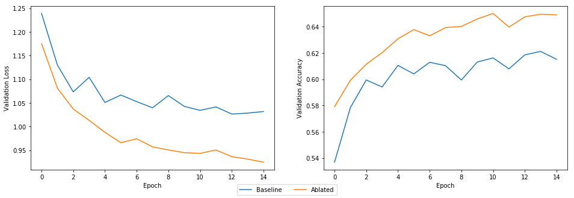

```python
fig, axs = plt.subplots(1, 2, figsize=(16, 5))

baseline_val_loss_hist = pt_stats['val_loss_history']
ablated_val_loss_hist = ablated_pt_stats['val_loss_history']
loss_data = np.array([baseline_val_loss_hist, ablated_val_loss_hist]).T

baseline_val_acc_hist = pt_stats['val_acc_history']
ablated_val_acc_hist = ablated_pt_stats['val_acc_history']
acc_data = np.array([baseline_val_acc_hist, ablated_val_acc_hist]).T

sns.lineplot(ax=axs[0], data=loss_data, dashes=False, legend=False)
axs[0].set_xlabel('Epoch')
axs[0].set_ylabel('Validation Loss')

sns.lineplot(ax=axs[1], data=acc_data, dashes=False, legend=False)
axs[1].set_xlabel('Epoch')
axs[1].set_ylabel('Validation Accuracy')

fig.legend(['Baseline', 'Ablated'], loc='lower center', ncol=2)
```

From the plots above, we can see that after training the ablated version of our network on the same training data, using the same hyperparameters, and evaluating it on the same validation data as our baseline, that it outperforms the baseline. In particular, the ablated version achieves a lower validation loss and a higher accuracy on all of the epochs, compared to the baseline model.

This suggests that the fully connected layers are actually hindering our model's performance slightly, and most of the performance is achieved by the convolutional layers. This is in line with the findings of [7], where Girshick et al. perform an ablation study on a CNN, removing two fully connected layers and find that the results are comparble to their baseline non-ablated network, leading them to say *"Much of the CNN’s representational power comes from its convolutional layers, rather than from the much larger densely connected layers."*

While we do not re-train our baseline and Tropic Zone models using the ablated version of the CNN, it is useful to know that we can simplify our network while retaining similar performance, for future experiments.

#### Additional insights

- **How does your model perform?:** From our hypothesis experiment we can see that our model performs quite well. Specifically, both our baseline and Tropic zone pre-trained models enable the fine-tuned models on each Sub-Saharan country to pefrom well, with an average accuracy above 70% in both cases. Moreover, both approaches achieve an average F1 score above 65% which shows the model has good performance, on the 17-way classification problem, even when taking into account the class imbalance observed during our data exploration.
- **Is there any room for improvement?:** We believe there is still room for improvement, both in terms of:
  1. increasing the evaluation scores even further while holding the amount of training data fixed; or
  2. by decreasing the amount of training data and achieving similar evaluation scores.
- **If so, what do you think is needed?:**
  1. To increase the evaluation score, while using the same amount of training data, we believe it would be useful to run the training for more epochs. Since we only had access to a CPU we ran training for 15 epochs, however from our plots for the baseline and Tropic Zone pre-trained models it appears the accuracy may continue to increase if training were to continue for longer. As such we would suggest performing training on a GPU for a greater number of epochs, e.g. 300, and implementing early stopping to stop training once the loss on the validation set is no longer decreasing beyond a given tolerance.
  2. When testing our hypothesis, we saw from our results that we can reduce the amount data needed to pre-train a model and obtain comparable results to using a larger dataset. However, for fine-tuning the model for the test countires, we still used around 250-750 points from each test country. To decrease the amount of data needed for fine-tuning we believe it would be interesting to combine our technique of using training data from the same climate zone as the test countries with the Wang et al. [1] meta-learning technique for training the pre-trained model. This may allow the dataset used during meta-training to be smaller, while still enabling few-shot fine-tuning for each test country. It would be useful to investigate whether a combination of the two approaches results in comparbale performance with fewer data being used/required.
- **Is training data enough for such an application?** The task being aimed at by this dataset is not only the land cover classification of geographic points, but also performing the classification with as few training samples as possible. Due to this we think that the volume of data provided is enough, but we think additional features should be added during training. Concretely, a simple addition would be including the latitude and longitude coordinates as features during training, as the location of where the wavelength measurements were taken is useful information for the purposes of land cover classification. Additional data which would be useful, but need to be separately sourced, is the weather data associated with the wavelength measurements, e.g. the temparature, humidity, rain fall. This data may be difficult to source for some countires especially at the 8-day interval level used by MODIS, therefore we would suggest using average weather information for the relevant year e.g. for our data set we could try and find the average temparature, average humdity and annual rainfall in 2018 for each region.
- **Do you think model's performance is enough for the application that you are aiming to address?:** We think the model's current performance would still need to be improved before it is enough for the application we are aiming to address. Specifically, we would need to discuss the performance required by the relevant stakeholders and evaluate our model's performance against that. For example, while we have developed a model which achieves an average accuracy over 70% in the test countries, the model users may want to see an average accuracy of at least 85%, or they may want an accuracy of at least 70% for each country / land cover type. However, once we have the minimum performance requirements we believe the model training could be modified to try and achieve these targets, by implementing the suggestions we have already discussed above.
- **Is the model scalable to a real-world application?:** Related to the previous point, we think the model is scalable to a real-world application since the model and training method are both quite simple. In particular, the model does not require a large amount of compute for training, in fact we have been able to achieve good baseline performance using a single CPU and training for 15 epochs. One of the main aspects of the application is to classify land covers with as few training samples as possible, however the number of inference points may be high. Even if the number of points requiring inference is high, the fine-tuning of the pre-trained model for each test country can be parallelized allowing the model to scale.
- **Comment on how the model compares to previous baselines:** Using transfer learning our pre-trained Tropic Zone model achieved an average accuracy, F1 and kappa score of 0.72, 0.67 and 0.48 respectively after fine-tuning on the Sub-Saharan countries. Using a transfer learning approach for one of their baselines Wang et al. [1] achieved an average accuracy, F1 and kappa score of 0.65, 0.73 and 0.27 respectively. Comparing these results we see we achieve a higher average accuracy and kappa score, but a lower F1-score.  
  However, we have used a 17-way classification approach while Wang et al. [1] use a 1-shot 2-way classification appraoch, so this is not a fair direct comparison of metrics. Moreover, while we evaluate our model by calculating the average for each metric based on performance of the fine-tuned models on test countires, Wang et al. evaluate the performance of their model based on 515 randomly sampled 1-shot 2-way test tasks (i.e. 5 tasks from each of the 103 test countries). To make a fair comparison with Wang et al. we would need to evaluate our model on a common task type, and using the same test tasks.  
  We can however make a comparison in terms of data used; comparing the transfering learning approaches we use less data during pre-training, both for our baseline and Tropic Zone model, compared with Wang et al., while we both use the same amount of data for fine-tuning on the test countries. But the Wang et al. meta-learning approach uses less data as it only samples tasks from the meta-training set, rather than using the full set, for training and uses much fewer samples for fine-tuning on test countries, as it only requires one sample per land cover type per region.

### Ethical considerations (15%)

**Guidelines**: Discuss/analyse the ethical dimensions of the application: bias, fairness, interpretability, etc. Some of these may not be relevant, but we leave this for you to decide which ones would be the relevant ones to consider for the problem at hand. Here you could do a sensitivity/interpretability analysis of the model, to study the effect of different variables or examine whether there are any biases. You could also link this part with your exploratory data analysis, focusing on the ethical dimensions of the dataset rather than the model you built. Justify what your analysis tell us about these ethical dimensions.

**Our discussion**

**Bias**  
We believe the overall application is ethical. In particular, the process for data collection is to sample regions uniformly at random from across the globe and to then sample points within each region again uniformly at random, hence this process is unbiased. However, as we have noted in the data exploration section due the additional constraints of each region requiring at least two land cover types and not having more than 80% of the region covered by a single land cover type, this can means some countries can have more points in the dataset than is proportional to their land area on Earth. This can introduce some unintended bias in the dataset, as mentioned earlier one way we suggest to correct for this is to ensure that the percentage of points from each country is approximately equal to the percentage of the country's land area on Earth.

**Privacy**  
Another benefit for the dataset, in terms of ethical considerations, is privacy. The data consists of wavelength timeseries data rather than images of the Earth which are often collected from satelittes. Moreover, it is not possible to reconstruct images from the RGB wavelengths included in the dataset, since the data is only on single points (1D) on Earth, rather than for 2D regions. This means that visual tracking of people, either intended or unintended, is not possible with this data, thereby not violating people's privacy.

**Interpretability**  
We have used a deep learning approach to develop a model for this problem, and while such methods are effective at classification tasks, it is often difficult to interpret the decisions made by the model [8]. This can be a drawback if the approach were to be used for monitoring the Earth's land coverings. In particular, if the output from the model is used by governments and international bodies to monitor land coverings, we believe they would want to have some assurance that the classifications made by the model are accurate and reliable. While assurance can sometimes be provided to model users by way of interpreting *how* the model is making its decisions, e.g. this is often possible for Decision Trees, it is difficult in our case for a CNN.

Research is being done to provide methods for interpreting more complex ML models, one such example is the introduction of LIME by Ribeiro et al. [8]. LIME aims to explain the prediction of any classifier in an interpretable and faithful manner, by learning an interpretable model locally around the prediction. As an example, the authors show [8, Section 3.6] how a deep network for image classification can be interpreted, by the model highlighting which parts of the image it considered most when establishing the probability of each class the image could belong to.

Such explainations are very useful for text and image classifications, where human evaluation can verify the explaination provided by ML models. However, in our case the underlying data itself can be difficult for a human to interpret, for example looking at the time series wavelength plot in the Data Analysis section above we would struggle to make a classification from the data directly. Hence, without any interventions it would be difficult to provide assurance to users of our model as-is.

However, with some additional validation *statistical assurance* could be provided. For example, a random set of locations could be sampled and viewed by a person using satellite images to verify if their classification of the land covering matches that of the model. A statistically significant number of samples should be selected and verified to determine whether or not the model is performing to a suitable level, as defined by the organisations relying on the model's output. We demonstrate performing this process for a single example below.

```python
def classification(timeseries_data, model_fpath):
    """
    Perform land cover type classification for given
    time series data, using the trained model provided.

    Args:
        timeseries_data (array): Array containing MODIS
        time series wavelength data, and NDVI index.
        model_fpath (str): File path to trained model to
        use for land cover classification.

    Returns:
        classification (str): Land cover type classification
        of data, using given model.
    """
    # Initialise new model
    model = TimeSeriesCnnModel()
    # Load trained model parameters
    model.load_state_dict(torch.load(model_fpath))
    model.to(device)

    # Reshape data into shape expected by model
    timeseries_data = timeseries_data.reshape(1, 8, -1)
    # Model inference
    outputs = model(timeseries_data.float())
    _, pred = torch.max(outputs, 1)
    # Convert predicted label index to land cover string
    classification = lndcvr_types[pred.item()]

    return classification
```

Now that we have created a function to provide the land cover classification of time series data, given a trained model, we show that it can be difficult to interpret the output from the model.

```python
# Select time series data to classify. We will choose
# the sample used at the beginning of this coursework for example
box, landcover, fname = 'box670', 'woody_savannas', 'lat59.61874999469706_lon114.70966591840244.npy'
fpath = os.path.join(MODIS_FPATH, box, landcover, fname)
# Load the data
data = load_point(fpath)
land_cvr_pred = classification(data, baseline_model_path)
print(f'Baseline model prediction: {land_cvr_pred}')
```

```
Baseline model prediction: woody_savannas
```

As we can see from the output above, a user can see the model's classification for a sample however it is not possible to tell how the model obtained it. In the `classificaiton` function we could additionally print the weight assigned to each land cover type by the model, showing the user how confident it is in each cover type being the correct label. However, this would raise a secondary quesiton of: *how does the model obtain those weights?*, and not necessarily provide much more interpretability.

To overcome this drawback, we next describe a process by which statistical assurance could be provided to model users.

1. Determine a statistically signifcant number, $N$, of samples to test, and suitable level of performance based on the application and the users' desired confidence level
2. Select $N$ geographic points (lat/lon) uniformly at random on Earth
3. For each geographic point
   1. View the point visually using a satellite image e.g. from [Google Earth](https://earth.google.com/web/) and manually classify the point
   2. Obtain MODIS time series wavelength data for the point
   3. Load data via the `load_point` function defined above
   4. Classify point using the `classification` function defined above, and a trained model
   5. Check if the manual classifcation from A. and model classification from D. match
4. Determine overall percentage match between manual and model classification

If the model surpasses the threshold set out in 1. the users will have statistical assurance the model is performing at an acceptable level for their application. We now run through this process for one sample, as an example. As we are using the MODIS data from 2018, we randomly sample a geographic point from the 2018 data avilable to us, however the same process could be performed with more recent data. Altough we have access to the true label in this case, we completely ignore it for the demonstration of this process, as it would not be available to us in the real-world application.

```python
# Randomly select a geographic point from our dataset
r = np.random.randint(len(metadata))
# Extract the relevant details to get the point data from disk.
# We use the landcover type to find the data on disk, and ignore it otherwise
box, landcover, fname, lat, lon = metadata.iloc[r][['box', 'landcover', 'filename', 'lat', 'lon']]
fpath = os.path.join(MODIS_FPATH, box, landcover, fname)

# First we manually classify the point using Google Earth
print(f'Sampled point: {lat}, {lon}')
```

```
Sampled point: 58.752083328109684, -103.8128114337208
```

Viewing this sampled point in Google Earth we would classify this point as `permanent_wetlands` as it appears to be surrounded by vegitation and zooming out we can see there are many similar wetlands close by.

We note the Google Earth satellite image appears to be from 2007 rather than 2018, however this example is for demonstration only. In reality, the satelitte images should be from the same year as the MODIS data being used to classify the point using the ML model.

Next we classify the same point using our pre-trained baseline model.

```python
# Load the time series data
timeseries_data = load_point(fpath)
# Classify the point using our baseline model
lnd_cvr_pred = classification(timeseries_data, baseline_model_path)
print(f'Baseline model prediction: {lnd_cvr_pred}')
```

```
Baseline model prediction: permanent_wetlands
```

In this case we see that the manual and model classifications match, and the process above would be repeated similarly for the number of samples $N$ selected by the user.

### Sustainable development relevance & impact (15%)

**Guidelines**: Discuss what are the current challenges surrounding this dataset in terms of sustainable development and how can ML help overcome them? Additionally, bring out all of the things you have managed to do and understand from the experiments and connect them to sustainable development. Discuss what are the challenges of deploying such a model and how it could impact our progress towards achieving the sustainable development goals.

**Our discussion**

**SDG challenge and how ML can help**  
As mentioned above this dataset can help with working towards [SDG-15](https://sdgs.un.org/goals/goal15) (Life on Land), specifically monitoring the profile of land coverings across the World. We need to be able to survey and monitor the land covering of the Earth, however this seems unfeasbile to do manually in-person due to time, resource and accessibility constraints. However, with greater availability of satellite data it may be possible to perform this monitoring remotely using this data. While this is more feasible than in-person surveying of land, it introduces its own challenges in the shear volume of data that would have to be triaged and labelled on an ongoing basis, again making this approach extremely time consuming and impractical. However, such classification is a task ML is well-suited to, and indeed ML could overcome the challenges of time consumption and perform the classification in a timely and automated manner. The human effort would then move from classification to verification of model output, using a process similar to the one described above, and the amount of effort would significantly be reduced in moving to verification.

**Learnings from experiments in connection to SDGs**  
Through our analysis and experiments we have carried out:

- **Data exploration** - we critically analysed the data our ML model would utilise, making use of additional sources to check the representativeness of the dataset, in our case this was to see how the percentage of points from each country in the dataset tallied with actual land area percentage of countries. From the analysis we found some countries we over represented and some significantly under represented.  
  We believe the task of data exploration is especially important in terms of sustainable development (SD) as it is a global endeavour. As such, the data used in support of SD needs to be as representative as possible of the World, rather than of just what we can easily measure. Since if this is not the case the ML models which rely on this data will also propagate this misrepresentation and provide inaccurate predictions/metrics, thereby preventing accurate tracking of progress towards SD.
- **Model development** - in our model development the key insight we found was related to data usage in training our ML model. By using information related to the subject matter, in this case how climate can affect land cover appearance, the amount of data used to pre-train our model could be significantly reduced while achieving comparable results to our baseline model which used more than twice the amount of data. In using less data, this also reduced the training time, by more than a half, and hence also reduced the amount of energy used to train the model.  
  While ML models can improve performance by training on more data, this can increase compute resource requirements and become unsustainable for large scale applications. Hence, we believe it is worth using subject matter knowledge to investiagte whether a strategically smaller dataset could be used for model training, while achieving acceptable results, to make the application development more sustainable.
- **Model interpretability** - one of the ethical aspects we discussed in the last section was model interpretability. We saw that it can be difficult to see why a ML model has made a classification decision. We think this is an important consideration in the application of ML supporting the SDGs, the reason for this is that such applications have the potential to affect government policies e.g. target 13.2 states *"Integrate climate change measures into national policies, strategies and planning"*. If ML is deployed in support of this target, e.g. by being used to estimate indicator 13.2.2 *"Total greenhouse gas emissions per year"*, then its output could affect national policy decisions which in turn could impact businesses and citizens.  
  While it can be difficult to directly interpret decisions made by ML models, assurances could be provided by performing independent testing of trained models, for example as described in the previous section. In this way if ML is deployed in support of SDGs which affect people and/or policies, evidence-based assurance can be provided to show the application is performing as expected.

**Challenges of deploying such a model**  
There still remains a challenge however of resource usage. In particular, an ML approach to this problem would reduce human resource effort, but would require additional compute resource in its place. This compute resource is not only required for training, and periodically re-training the model, but also for the inference on hundreds-of-thousands of points across the globe. Such compute resource could require a significant amount of energy and depending on how that energy is sourced it could negatively impact other SDGs, e.g. [SDG-13](https://sdgs.un.org/goals/goal13) (Climate Action). While this a challenge we flag, we believe the environmental impact would be limited due to the size of model we use and the frequency with which inference would need to take place. The model used in our experiments is a small CNN, which is much smaller than many large Deep Learning models being used in other applications such as NLP, hence would require comparitively low energy to train.  
Moreover, by the nature of land cover classificaiton the inference of points would not need to occur frequently; if the real-world application were to use the MODIS dataset, then inference would be on a yearly basis as the timeseries data the model has been trained on requires wavelength data spanning a year. However, even if another data source is able to provide more frequent wavelength data we do not think land cover classification would need to take place on a minute-to-minute or even day-to-day basis, but more likely to be on a monthly or quartely basis, thereby limiting the amount of energy requried for classification.

### References

[1] [Meta-Learning For Few-Shot Time Series Classification, Wang et al.](https://ieeexplore.ieee.org/document/9441016)

[2] [Model-Agnostic Meta-Learning for Fast Adaptation of Deep Networks, Finn et al.](https://arxiv.org/abs/1703.03400)

[3] [Chapter 27 - Spatiotemporal Variability of Soil Moisture and Drought Estimation Using a Distributed Hydrological Model, Drisya et al., Section 27.4.1.1](https://www.sciencedirect.com/science/article/pii/B9780128120569000270#!)

[4] [Deep learning for time series classification: a review, Fawaz et al., Section 5.3](https://arxiv.org/pdf/1809.04356.pdf)

[5] J. Cohen (1960). “A coefficient of agreement for nominal scales”. Educational and Psychological Measurement.

[6] [Convolution Kernel Size Effect on Convolutional Neural Network in Histopathological Image Processing Applications, Öztürk et al.](https://ieeexplore.ieee.org/document/8742484)

[7] [Rich feature hierarchies for accurate object detection and semantic segmentation, Girshick et al.](https://arxiv.org/abs/1311.2524)

[8] [“Why Should I Trust You?” Explaining the Predictions of Any Classifier, Ribeiro et al.](https://arxiv.org/abs/1602.04938)